# Project 5 - Sheshank

```python
#This is the function I am going to use again and again, so before anything is said
#here is the detail.
#########################################################3
#########################################################
import multiprocessing
import time
############################################################
#############################################################
def mf(function):
    import time
    multiprocessing_func=function
    starttime = time.time()
    if __name__ == '__main__':
        processes = []
        for i in range(1,10):
            p = multiprocessing.Process(target=multiprocessing_func, args=(i,))
            processes.append(p)
            p.start()
        for process in processes:
            process.join()

    #print()
    print('Time taken = {} seconds\n'.format(time.time() - starttime))
    return multiprocessing_func
#######################################################################
#####################################################################

#multiprocessing_func(function) as mf(function) # function() is the function we want multiprocessed
```

```python
#Demonstration of the above function
#######################################################################
#######################################################################
def finding_primes_below(n,var=False):
    if var : starttime=time.time()
    j=2
    k1=True
    k2=True
    for i in range(n-1,-1,-1):
        if k1:
            if n%j==0:
                print("The lowest divisor is :",j)
                k1=False
            j+=1
        if k2:
            if n%i==0:
                print("The highest divisor is : ",i)
                k2=False
        if not(k1 or k2):
            if var : print('Time taken = {} seconds\n'.format(time.time() - starttime))
            break
    print("Successful Job Completion : No Multiprocessing Used\n") if var else print("Successful Job Completion : Multiprocessing Used\n")
    return j-1
#######################################################################
#######################################################################
k=mf(finding_primes_below(7879741))
print(k)
finding_primes_below(7879741,var=True)
```

```
The lowest divisor is : 7879741
The highest divisor is :  1
Successful Job Completion : Multiprocessing Used

Time taken = 0.12118792533874512 seconds

7879741
The lowest divisor is : 7879741
The highest divisor is :  1
Time taken = 0.8329687118530273 seconds

Successful Job Completion : No Multiprocessing Used
```

```
7879741
```

Acess the multiprocessing module to access faster and better processing speeds. Just remove the wrappers of mf()for any given function and you have this working.

I have found that the working is dramatically slowed down and the processor is only utilized for its single core because of how python was organized and setup. So, to get around and take advantage of all the available cores and do some parallel processing, I have chosen to taken multiprocessing module. But, it takes only only functions as inputs.

```python
#Importing some modules here, but rest will be imported as per the requirement
import pandas as pd
import numpy as np
import seaborn as sns
import matplotlib.pyplot as plt
%matplotlib inline
import scipy.stats as stats
```

```python
data1=pd.read_csv("signal-data.csv")
```

```python
data1.shape
```

```
(1567, 592)
```

```python
any(data1.dtypes=="object") #Indicating the non numerical columns
```

```
True
```

```python
data1.head()
```

|  | Time | 0 | 1 | 2 | 3 | 4 | 5 | 6 | 7 | 8 | ... | 581 | 582 | 583 | 584 | 585 | 586 | 587 | 588 | 589 | Pass/Fail |
| --- | --- | --- | --- | --- | --- | --- | --- | --- | --- | --- | --- | --- | --- | --- | --- | --- | --- | --- | --- | --- | --- |
| 0 | 2008-07-19 11:55:00 | 3030.93 | 2564.00 | 2187.7333 | 1411.1265 | 1.3602 | 100.0 | 97.6133 | 0.1242 | 1.5005 | ... | NaN | 0.5005 | 0.0118 | 0.0035 | 2.3630 | NaN | NaN | NaN | NaN | -1 |
| 1 | 2008-07-19 12:32:00 | 3095.78 | 2465.14 | 2230.4222 | 1463.6606 | 0.8294 | 100.0 | 102.3433 | 0.1247 | 1.4966 | ... | 208.2045 | 0.5019 | 0.0223 | 0.0055 | 4.4447 | 0.0096 | 0.0201 | 0.0060 | 208.2045 | -1 |
| 2 | 2008-07-19 13:17:00 | 2932.61 | 2559.94 | 2186.4111 | 1698.0172 | 1.5102 | 100.0 | 95.4878 | 0.1241 | 1.4436 | ... | 82.8602 | 0.4958 | 0.0157 | 0.0039 | 3.1745 | 0.0584 | 0.0484 | 0.0148 | 82.8602 | 1 |
| 3 | 2008-07-19 14:43:00 | 2988.72 | 2479.90 | 2199.0333 | 909.7926 | 1.3204 | 100.0 | 104.2367 | 0.1217 | 1.4882 | ... | 73.8432 | 0.4990 | 0.0103 | 0.0025 | 2.0544 | 0.0202 | 0.0149 | 0.0044 | 73.8432 | -1 |
| 4 | 2008-07-19 15:22:00 | 3032.24 | 2502.87 | 2233.3667 | 1326.5200 | 1.5334 | 100.0 | 100.3967 | 0.1235 | 1.5031 | ... | NaN | 0.4800 | 0.4766 | 0.1045 | 99.3032 | 0.0202 | 0.0149 | 0.0044 | 73.8432 | -1 |

5 rows × 592 columns

```python
data1.tail()
```

|  | Time | 0 | 1 | 2 | 3 | 4 | 5 | 6 | 7 | 8 | ... | 581 | 582 | 583 | 584 | 585 | 586 | 587 | 588 | 589 | Pass/Fail |
| --- | --- | --- | --- | --- | --- | --- | --- | --- | --- | --- | --- | --- | --- | --- | --- | --- | --- | --- | --- | --- | --- |
| 1562 | 2008-10-16 15:13:00 | 2899.41 | 2464.36 | 2179.7333 | 3085.3781 | 1.4843 | 100.0 | 82.2467 | 0.1248 | 1.3424 | ... | 203.1720 | 0.4988 | 0.0143 | 0.0039 | 2.8669 | 0.0068 | 0.0138 | 0.0047 | 203.1720 | -1 |
| 1563 | 2008-10-16 20:49:00 | 3052.31 | 2522.55 | 2198.5667 | 1124.6595 | 0.8763 | 100.0 | 98.4689 | 0.1205 | 1.4333 | ... | NaN | 0.4975 | 0.0131 | 0.0036 | 2.6238 | 0.0068 | 0.0138 | 0.0047 | 203.1720 | -1 |
| 1564 | 2008-10-17 05:26:00 | 2978.81 | 2379.78 | 2206.3000 | 1110.4967 | 0.8236 | 100.0 | 99.4122 | 0.1208 | NaN | ... | 43.5231 | 0.4987 | 0.0153 | 0.0041 | 3.0590 | 0.0197 | 0.0086 | 0.0025 | 43.5231 | -1 |
| 1565 | 2008-10-17 06:01:00 | 2894.92 | 2532.01 | 2177.0333 | 1183.7287 | 1.5726 | 100.0 | 98.7978 | 0.1213 | 1.4622 | ... | 93.4941 | 0.5004 | 0.0178 | 0.0038 | 3.5662 | 0.0262 | 0.0245 | 0.0075 | 93.4941 | -1 |
| 1566 | 2008-10-17 06:07:00 | 2944.92 | 2450.76 | 2195.4444 | 2914.1792 | 1.5978 | 100.0 | 85.1011 | 0.1235 | NaN | ... | 137.7844 | 0.4987 | 0.0181 | 0.0040 | 3.6275 | 0.0117 | 0.0162 | 0.0045 | 137.7844 | -1 |

5 rows × 592 columns

```python
#data1_cols=data1.columns
data1[data1["Pass/Fail"].isna()]
#We have no empty columns meaning that there are no data points where the Pass/Fail case is not recroded.
```

|  | Time | 0 | 1 | 2 | 3 | 4 | 5 | 6 | 7 | 8 | ... | 581 | 582 | 583 | 584 | 585 | 586 | 587 | 588 | 589 | Pass/Fail |
| --- | --- | --- | --- | --- | --- | --- | --- | --- | --- | --- | --- | --- | --- | --- | --- | --- | --- | --- | --- | --- | --- |

0 rows × 592 columns

```python
data1_wo=data1.drop(["Time"],axis=1)
data1_wo_=data1.drop(["Time","Pass/Fail"],axis=1) #Dataframe without non Numerical Valued columns
data1_wo_
```

|  | 0 | 1 | 2 | 3 | 4 | 5 | 6 | 7 | 8 | 9 | ... | 580 | 581 | 582 | 583 | 584 | 585 | 586 | 587 | 588 | 589 |
| --- | --- | --- | --- | --- | --- | --- | --- | --- | --- | --- | --- | --- | --- | --- | --- | --- | --- | --- | --- | --- | --- |
| 0 | 3030.93 | 2564.00 | 2187.7333 | 1411.1265 | 1.3602 | 100.0 | 97.6133 | 0.1242 | 1.5005 | 0.0162 | ... | NaN | NaN | 0.5005 | 0.0118 | 0.0035 | 2.3630 | NaN | NaN | NaN | NaN |
| 1 | 3095.78 | 2465.14 | 2230.4222 | 1463.6606 | 0.8294 | 100.0 | 102.3433 | 0.1247 | 1.4966 | -0.0005 | ... | 0.0060 | 208.2045 | 0.5019 | 0.0223 | 0.0055 | 4.4447 | 0.0096 | 0.0201 | 0.0060 | 208.2045 |
| 2 | 2932.61 | 2559.94 | 2186.4111 | 1698.0172 | 1.5102 | 100.0 | 95.4878 | 0.1241 | 1.4436 | 0.0041 | ... | 0.0148 | 82.8602 | 0.4958 | 0.0157 | 0.0039 | 3.1745 | 0.0584 | 0.0484 | 0.0148 | 82.8602 |
| 3 | 2988.72 | 2479.90 | 2199.0333 | 909.7926 | 1.3204 | 100.0 | 104.2367 | 0.1217 | 1.4882 | -0.0124 | ... | 0.0044 | 73.8432 | 0.4990 | 0.0103 | 0.0025 | 2.0544 | 0.0202 | 0.0149 | 0.0044 | 73.8432 |
| 4 | 3032.24 | 2502.87 | 2233.3667 | 1326.5200 | 1.5334 | 100.0 | 100.3967 | 0.1235 | 1.5031 | -0.0031 | ... | NaN | NaN | 0.4800 | 0.4766 | 0.1045 | 99.3032 | 0.0202 | 0.0149 | 0.0044 | 73.8432 |
| ... | ... | ... | ... | ... | ... | ... | ... | ... | ... | ... | ... | ... | ... | ... | ... | ... | ... | ... | ... | ... | ... |
| 1562 | 2899.41 | 2464.36 | 2179.7333 | 3085.3781 | 1.4843 | 100.0 | 82.2467 | 0.1248 | 1.3424 | -0.0045 | ... | 0.0047 | 203.1720 | 0.4988 | 0.0143 | 0.0039 | 2.8669 | 0.0068 | 0.0138 | 0.0047 | 203.1720 |
| 1563 | 3052.31 | 2522.55 | 2198.5667 | 1124.6595 | 0.8763 | 100.0 | 98.4689 | 0.1205 | 1.4333 | -0.0061 | ... | NaN | NaN | 0.4975 | 0.0131 | 0.0036 | 2.6238 | 0.0068 | 0.0138 | 0.0047 | 203.1720 |
| 1564 | 2978.81 | 2379.78 | 2206.3000 | 1110.4967 | 0.8236 | 100.0 | 99.4122 | 0.1208 | NaN | NaN | ... | 0.0025 | 43.5231 | 0.4987 | 0.0153 | 0.0041 | 3.0590 | 0.0197 | 0.0086 | 0.0025 | 43.5231 |
| 1565 | 2894.92 | 2532.01 | 2177.0333 | 1183.7287 | 1.5726 | 100.0 | 98.7978 | 0.1213 | 1.4622 | -0.0072 | ... | 0.0075 | 93.4941 | 0.5004 | 0.0178 | 0.0038 | 3.5662 | 0.0262 | 0.0245 | 0.0075 | 93.4941 |
| 1566 | 2944.92 | 2450.76 | 2195.4444 | 2914.1792 | 1.5978 | 100.0 | 85.1011 | 0.1235 | NaN | NaN | ... | 0.0045 | 137.7844 | 0.4987 | 0.0181 | 0.0040 | 3.6275 | 0.0117 | 0.0162 | 0.0045 | 137.7844 |

1567 rows × 590 columns

```python
######################################################3
for each in data1.columns:
    #print(each)
    if data1[each].dtypes !="float64":
        print(each)
#############################################################
 #Only first column is an object column which is a Time Stamp which can be dropped for now. The other columns seems to be
```

```
Time
Pass/Fail
```

# Data Exploration and Analysis

```python
data1_target=data1[data1["Pass/Fail"]==1] #Dataframe containing the actual fail cases.
data1_target_wo=data1_target.drop(["Time","Pass/Fail"],axis=1) #Dataframe of fail cases without the columns for actual processing
data1_notarget=data1[data1["Pass/Fail"]==-1] #Dataframe containing the pass cases
data1_notarget_wo=data1_notarget.drop(["Time","Pass/Fail"],axis=1) #Dataframe of pass cases without the columns for actual processing.
```

**Note** : Attempt is made here to see if the missing values under any case (I refer to it as case Scenario) has any kind of relation with the outcome of the manufacuting process.

```python
#
################################################################
empty_data_failure=[] #Data of the columns with NaN in Failure Case Dataframe
for cols in data1.columns:
    empty_data_failure.append([cols,list(data1_target[data1_target[cols].isna()==True].index)])

#####################################################
empty_data_pass=[] #Data of the columns with NaN in Pass Case Dataframe
for cols in data1.columns:
    empty_data_pass.append([cols,list(data1_notarget[data1_notarget[cols].isna()==True].index)])

########################################################
empty_data_all=[] # Data of columns with NaN in Original Dataframe
for cols in data1.columns:
    empty_data_all.append([cols,list(data1_wo_[data1[cols].isna()==True].index)])

########################################################

########################################################
for each in empty_data_failure[1:591]:
    if not len(each[1]):
        #print(each)
        empty_data_failure.remove(each)
        #print(empty_data_w)
#To Remove empty fillings if any inside the indexex
###############################################################

##############################################################

for each in empty_data_pass[1:591]:
    if not len(each[1]):
        #print(each)
        empty_data_pass.remove(each)
        #print(empty_data_w)
#To Remove emty fillings if any inside the index
##############################################################
empty_data_failure_wo=empty_data_failure[1:591] #Dataframe index list of Fail Case NaN values
empty_data_pass_wo=empty_data_pass[1:591] # Dataframe Index of pass case with NaN Values
```

```python
##############################################################
NaN_pass=[] #List of NaN Values Index in Pass case
for each in empty_data_pass_wo:
    #print(each)
    for item in each[1]:
        #print(item)
        NaN_pass.append(item)
##############################################################
NaN_pass=list(set(NaN_pass))

##############################################################

##############################################################
NaN_fail=[] #List of NaN Values Index in failure case
for each in empty_data_failure_wo:
    #print(each)
    for item in each[1]:
        #print(item)
        NaN_fail.append(item)
###########################################################
NaN_fail=list(set(NaN_fail)) #Index of the values for which there needs to be some immediate and appropriate treatements for NaN values.
```

```python
data1_target_w_nan=data1_target_wo.loc[NaN_fail] #these are the cases with NaN values within the Failure case dataframe that might be directly connected.
```

```python
data1_target_wo.drop(data1_target_w_nan.index)
#
```

|  | 0 | 1 | 2 | 3 | 4 | 5 | 6 | 7 | 8 | 9 | ... | 580 | 581 | 582 | 583 | 584 | 585 | 586 | 587 | 588 | 589 |
| --- | --- | --- | --- | --- | --- | --- | --- | --- | --- | --- | --- | --- | --- | --- | --- | --- | --- | --- | --- | --- | --- |

0 rows × 590 columns

This is giving a very important suggestion that for fail cases atleast one of the sensor data might be missing, we have to verify it.

```
The percentage of data that represents the actual failure is : 6.636885768985322 %
```

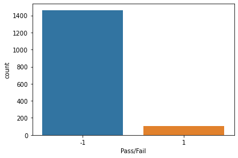

```python
sns.countplot(x=data1["Pass/Fail"])

print("The percentage of data that represents the actual failure is :",(data1_target.shape[0])*100/(data1.shape[0]),"%")
```

So, the amount of data that actually represents the failure within the given data is disproportionately small. So, we will have to adjust it by sampling such that Machine learning model won't be overwhelmed by the presence of the True values or data skewness.

```python
[data1_target_w_nan.index].sort()==[item for item in data1_target.index].sort()
#
```

```
True
```

Looks like all of the failure cases have some sort missing data in one or the other of the columns

```python
data1[data1[data1.columns[-1]].isna()]
#
```

|  | Time | 0 | 1 | 2 | 3 | 4 | 5 | 6 | 7 | 8 | ... | 581 | 582 | 583 | 584 | 585 | 586 | 587 | 588 | 589 | Pass/Fail |
| --- | --- | --- | --- | --- | --- | --- | --- | --- | --- | --- | --- | --- | --- | --- | --- | --- | --- | --- | --- | --- | --- |

0 rows × 592 columns

Apparently there are no cases where the data is not available for the Pass/Failure cases column. That means the particular column is always filled.

**Observations**:

# Assumptions and Pre-positions

Before we proceed we have some very strong assumptions to make regarding the data so that model might stay relevant.

1. Our Data prediction model is supposed to model only this manufacturing, hence these models can only be used for prediction of this particular product only. For different products, even using the same sensors, we might need different machine learning models.
2. Data corresponds to only type of manufacturing product and not different types and machines are always operated appropriately.
3. There might be some problem with Sensors or readings or both or none. Exact problem can't be identified unless we have domain knowledge and specified on the ground understanding of what these sensors represent.

# Strategy and Approach

**Notes** :

From my functional knowledge of the manufacturing processes in general and the nature of the IoT devices and their connections, there are some considerations that can be made here, and the corresponding chain of thought to be explored for a given data. We can't be sure any single idea or a combination of all of them might lead to failure case.

1. Sensors often loose calibration which might drop them dead and lead them to not report values at all, or even if they report they might be dogmatic or wild swings. That unusual patterns need to be checked and correspondence to the output need to be checked.
2. Sometimes Sensors are pushed beyond their resolution, meaning that sensors might not sense the subtle changes at all, individually, but collectively, they might be able to brighten our chances of detecting subtle changes. In this process there is a real chance that some sensors might outshine others in their contribution towards some kind of sum total, those need to be appropriately studied.
3. There is a realistic chance that sensors might have lost their sensitivity or resolution because of some unusual exposure to a particular datapoint, and might have taken some time to settle down to its normal value, probably resulting in erroneous reporting. These can be evidenced in the Pass case (particularly) and might have been misreported of any anamoly. Hence it becomes important to see how pass/fail are distributed in time.
4. Usually very frequent datapoint collection, sometimes too frequent might produce some kind of interference in the data of a sensors with its own previous data creating a feedback loop for a number of cycles with almost same values. But, this pattern is extremely hard to detect and can very easily be disguised (also easily be mistaken for a abnormal reading).
5. Since Failure case and Pass case and disproportinately represented, we should look for anamolies within them, in parallel, side by side manner and compare.

**Strategy (Rough outlook)** :

1. First have a look at the data and check if they form any clusters around the data point that separates Pass case and fail case. If there are any on-the-face indicators of something being a pass case and fail case.
2. Explore the options of how the manufacturing has progressed and when it happened, i.e. a kind of time series analysis and observe some pattern. (No further analysis will be undertaken here)
3. Since the manufacturing processes are usually pretty much decided beforehand of exact proportions and we are not looking at raw or wild data but at very much expanded data. I am Assuming here that manufacturing process is tuned perfectly to the precision before these sensors were set into motion. So, there is always a set expected value for each sensor no matter what. This means that not much variations are expected within the data (in Data Science terminology, the max,min values should be within acceptable range and anything other than that is to be a serious suspect).
4. Expected value is always one particular sensor value, so anything that doesn't a very high modal count, or that there more than usual number of modes (equal in number to total number of datapoints) can be taken with suspicion for cause of the failure.
5. Almost all of the readings here are continuous values, so variations are going to be subtle, hence we can ignore them, until we find no variations at all. The mode has to be compared - not in a direct way - with the mean value. If they seem to be close enough or not (how close is close enough is a BIG question that I don't know the answer for), especially in the situations of fail case and pass case separately, and note down. If they are close enough, they can easily be replaced by their corresponding modal values (a strong reason is because modal value is expected from the sensor - especially in the pass case scenario).
6. If the above doesn't workout, then we can simply replace it by average/mean value and that can be asserted to be expected value. But we have to do them separately for fail case and pass case, with their corresponding respective means and modes.
7. Then do the minmax or zscore scaler, or do whatever is necessary.
8. Select a bunch of models from supervised learning and figure out through PCA or some other means to select principal components, do some Eigen Transformations, and make the data ready.
9. Do some Hyperparameter tuning, to select for the best fit parameters.
10. Once we have that we can loop it around for bootstrap sampling. We can simultaneously go for lasso or ridge cross validation to prepare the datasets for the real model. Set up appropriate functions that perform all this.
11. After all this observe data, predictive models and their performance across the various considerations and finalize the parameters, and set up a list of these in appropriate order.
12. Create a pipeline for all this in a step by step manner : a. Take and eliminate uselessdata b.scaling c.Feature Selection d. model selection e. model evluation f.model tuning g.model storage
13. (optional)Create Multiple pipelines for multiple models.
14. Create a parameters grid, model performance parameters, suggestions on which model to choose. Depending upon the chosen model, proceed further.
15. Create a pickled file and store it for future usage.
16. Check the test set data given to us and test it against it.

**Assumptions Made**: I am making here a small assumption that all the columns here represent different sensors and they create an network of things that feed continuous data into the Mainframe system. So, hereby refer to each column as a Sensor

Starting it out with generation feel for the total summation and values, if any particular sensors dominate other, are there any clusters, peak points etc. If so, do they correspond to the pass/fail case scenario.

**Summation/Average Value Analysis**

```python
#######################################################################
########################################################################

def data_info_out(dataframe):
    print("Maximum Total Value for the Sensors",dataframe.T.sum().max()) #Sum Total of all the sensor values max
    print("Minimum Total Value for the Sensors",dataframe.T.sum().min()) #Sum Total of all the Sensor Values min
    print("Maximum Average Value for the Sensors",dataframe.T.sum().max()/data1_target_wo.shape[1]) #Maximum Average value per Sensor
    print("Minimum Average Value for the Sensors",dataframe.T.sum().min()/data1_target_wo.shape[1]) #Sum Total of all the sensor values max

#######################################################################
########################################################################
```

```
In Failure Case Scenario
Maximum Total Value for the Sensors 84136.3079
Minimum Total Value for the Sensors 30164.03
Maximum Average Value for the Sensors 142.60391169491524
Minimum Average Value for the Sensors 51.12547457627119


In Pass Case Scenario
Maximum Total Value for the Sensors 120648.1563
Minimum Total Value for the Sensors 22172.598599999998
Maximum Average Value for the Sensors 204.48840050847457
Minimum Average Value for the Sensors 37.580675593220334
```

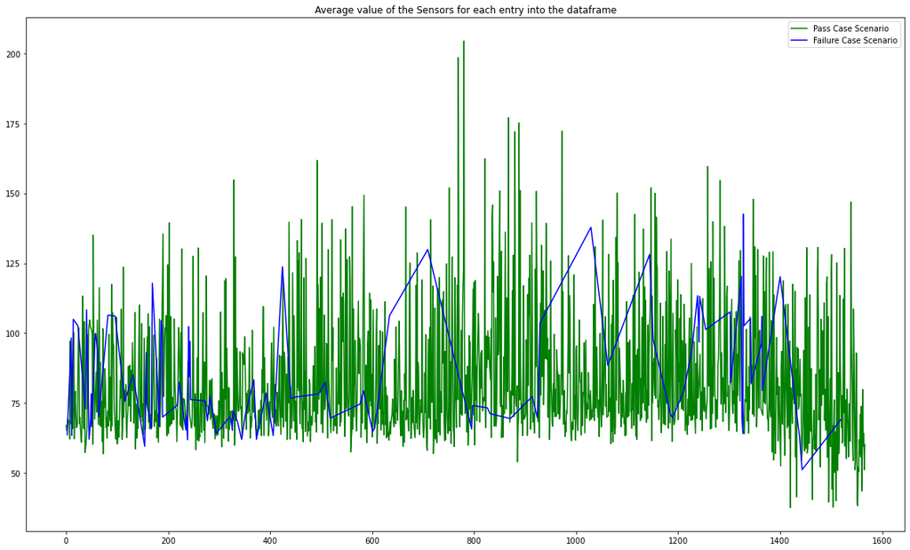

```python
print("In Failure Case Scenario")
data_info_out(data1_target_wo) #Sum total value for failure case scenario
print("\n")
print("In Pass Case Scenario")
data_info_out(data1_notarget_wo) #Sum total value for the Pass case Scenario
print("\n")
plt.figure(figsize=(20,12))
plt.title("Average value of the Sensors for each entry into the dataframe")
plt.plot((data1_notarget_wo.T.sum()/data1_notarget_wo.shape[1]),'g',label="Pass Case Scenario")
#plt.set(xlabel="Datapoints",ylabel="Avg value")
#print("\n")
plt.plot((data1_target_wo.T.sum()/data1_target_wo.shape[1]),'b',label="Failure Case Scenario")
#plt.set_xlabel("Datapoints")
plt.legend()
plt.show()
```

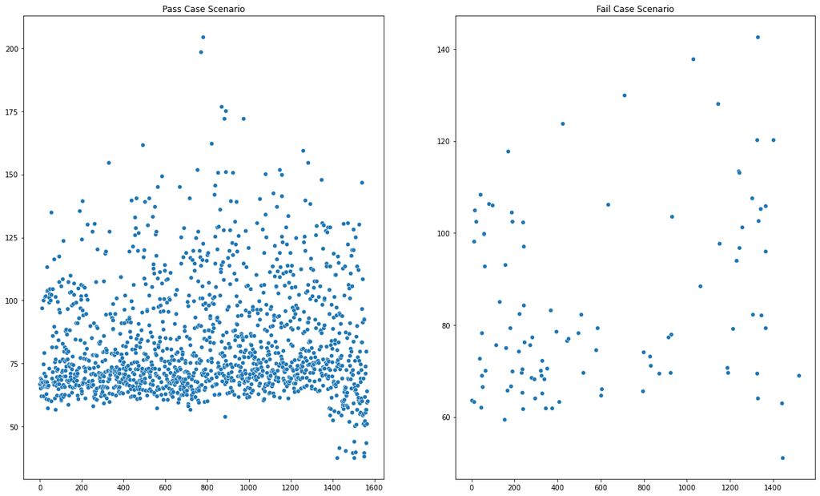

```python
plt.figure(figsize=(20,12))
plt.subplot(1,2,1)
sns.scatterplot(data=(data1_notarget_wo.T.sum()/data1_notarget_wo.shape[1])) #Checking if there are any clusters in pass case
plt.title("Pass Case Scenario")
plt.subplot(1,2,2)
sns.scatterplot(data=(data1_target_wo.T.sum()/data1_target_wo.shape[1])) #Fail case scenario checking for clusters
plt.title("Fail Case Scenario")
plt.show()
```

**Observations** :

1. Interesting Scenarios emerge at three peaks, we need to separate them as plot them as a grid. Let us now plot those case entries where, if there is any correlation between the quantities or not.
2. Scatterplot indicates no particular clustering at all. But, there is a tiny indication that probably the failure case is indicated by sensors reading outlier values. This remains to be seen and verified.

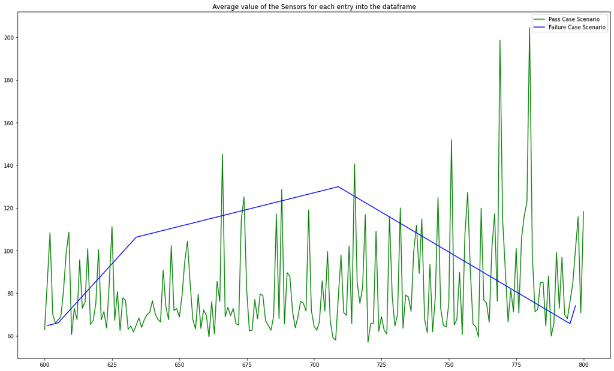

```python
plt.figure(figsize=(20,12))
plt.title("Average value of the Sensors for each entry into the dataframe")
plt.plot((data1_notarget_wo.T.sum()/data1_notarget_wo.shape[1]).loc[600:800],'g',label="Pass Case Scenario")
#print("\n")
plt.plot((data1_target_wo.T.sum()/data1_target_wo.shape[1]).loc[600:800],'b',label="Failure Case Scenario")
plt.legend()
plt.show()
```

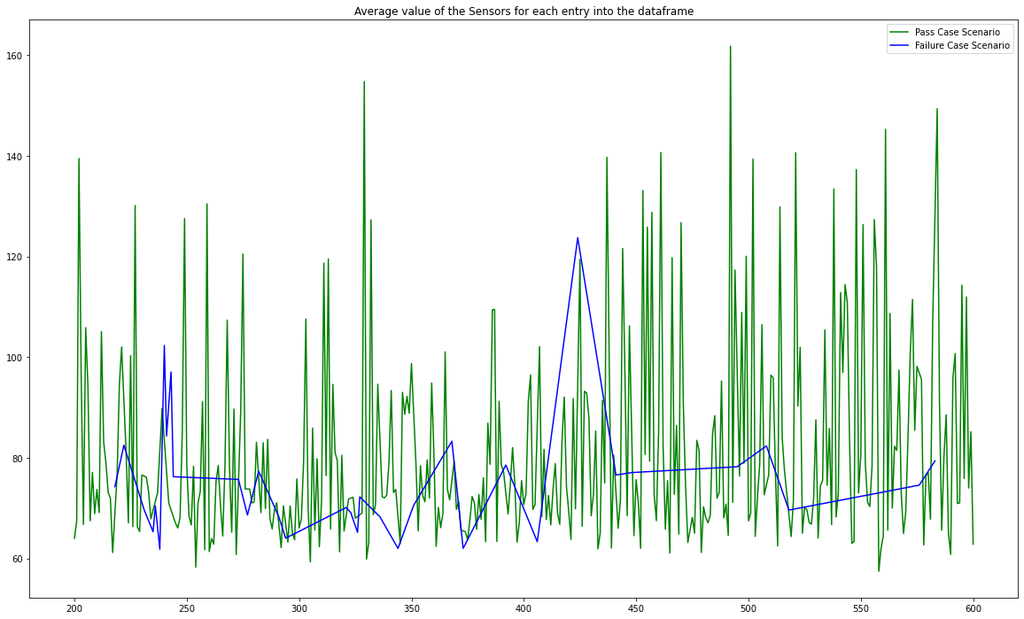

```python
plt.figure(figsize=(20,12))
plt.title("Average value of the Sensors for each entry into the dataframe")
plt.plot((data1_notarget_wo.T.sum()/data1_notarget_wo.shape[1]).loc[200:600],'g',label="Pass Case Scenario")
#print("\n")
plt.plot((data1_target_wo.T.sum()/data1_target_wo.shape[1]).loc[200:600],'b',label="Failure Case Scenario")
plt.legend()
plt.show()
```

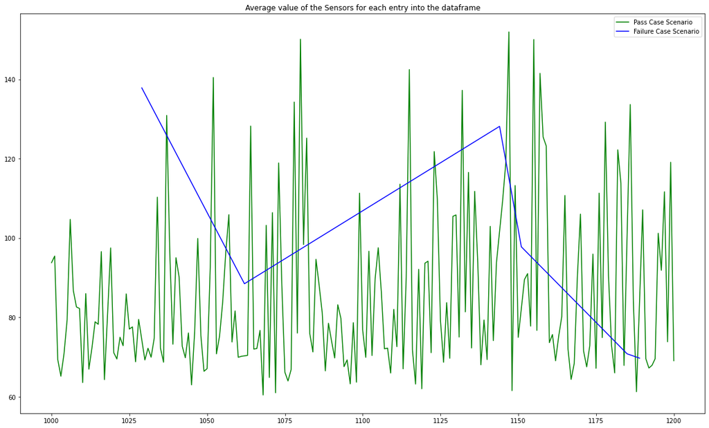

```python
plt.figure(figsize=(20,12))
plt.title("Average value of the Sensors for each entry into the dataframe")
plt.plot((data1_notarget_wo.T.sum()/data1_notarget_wo.shape[1]).loc[1000:1200],'g',label="Pass Case Scenario")
#print("\n")
plt.plot((data1_target_wo.T.sum()/data1_target_wo.shape[1]).loc[1000:1200],'b',label="Failure Case Scenario")
plt.legend()
plt.show()
```

```python
######################################################################
#This provides horizontal datarange slices for individual data entry points,
#especially in the light that there might be some connection. Can be used for further analysis.
#
###############################################################
################################################################
def slice_ranges(dataframe1,dataframe2,range_slices=5):
    slice_ranges=[]
    highvalue=dataframe1.shape[0]
    lowvalue=0
    rangevalue=int(highvalue/5)
    remaindervalue=highvalue%5
    for i in range(lowvalue,highvalue,rangevalue):
        if rangevalue+lowvalue>highvalue:
            slice_ranges.append([(i,rangevalue+lowvalue),[dataframe1.loc[i:],dataframe2.loc[i:]]])
        else:
            slice_ranges.append([(i,rangevalue+lowvalue),dataframe1.loc[i:i+rangevalue],dataframe2.loc[i:i+rangevalue]])
    return slice_ranges
#######################################################################
#######################################################################
```

**Looking at Data Descriptions**

We have to look at the next stage i.e. the description of the data in considerable detail.

**Warning** : It is impossible to plot the data or be able to figure out someting. Visual analysis only helps AFTER we find anamolies to verify them. Without them, we simply have no place at all for visual analysis. So, first we should do some mathematical analysis and look for commonly exhibited anamolies and go step by step.

```python
data1_notarget_wo.describe().T
```

|  | count | mean | std | min | 25% | 50% | 75% | max |
| --- | --- | --- | --- | --- | --- | --- | --- | --- |
| 0 | 1457.0 | 3014.947316 | 72.461809 | 2743.2400 | 2968.78000 | 3012.68000 | 3057.030000 | 3356.3500 |
| 1 | 1457.0 | 2495.906115 | 81.033476 | 2158.7500 | 2452.15000 | 2499.15000 | 2539.460000 | 2846.4400 |
| 2 | 1449.0 | 2200.554886 | 29.391944 | 2060.6600 | 2181.18890 | 2201.06670 | 2218.055500 | 2315.2667 |
| 3 | 1449.0 | 1399.290292 | 447.984948 | 0.0000 | 1081.87580 | 1285.21440 | 1591.223500 | 3715.0417 |
| 4 | 1449.0 | 4.404698 | 58.338675 | 0.6815 | 1.01600 | 1.31680 | 1.529100 | 1114.5366 |
| ... | ... | ... | ... | ... | ... | ... | ... | ... |
| 585 | 1462.0 | 3.063023 | 3.684206 | 1.1975 | 2.31185 | 2.75765 | 3.281525 | 99.3032 |
| 586 | 1462.0 | 0.021445 | 0.012426 | -0.0169 | 0.01340 | 0.02050 | 0.027500 | 0.1028 |
| 587 | 1462.0 | 0.016392 | 0.008822 | 0.0032 | 0.01060 | 0.01480 | 0.020000 | 0.0799 |
| 588 | 1462.0 | 0.005260 | 0.002877 | 0.0010 | 0.00330 | 0.00460 | 0.006400 | 0.0286 |
| 589 | 1462.0 | 99.736495 | 94.830589 | 0.0000 | 44.31625 | 71.67665 | 114.749700 | 737.3048 |

590 rows × 8 columns

```python
data1_target_wo.describe().T
```

|  | count | mean | std | min | 25% | 50% | 75% | max |
| --- | --- | --- | --- | --- | --- | --- | --- | --- |
| 0 | 104.0 | 3007.526250 | 88.409688 | 2848.4600 | 2946.120000 | 2989.31500 | 3053.280000 | 3266.5500 |
| 1 | 103.0 | 2495.059709 | 71.316362 | 2286.2500 | 2457.785000 | 2500.85000 | 2532.010000 | 2714.3000 |
| 2 | 104.0 | 2200.441877 | 31.302444 | 2138.8778 | 2173.480575 | 2196.68890 | 2218.936075 | 2315.2667 |
| 3 | 104.0 | 1355.781435 | 341.306204 | 899.9488 | 1069.645950 | 1281.53680 | 1558.445325 | 2360.1325 |
| 4 | 104.0 | 1.303405 | 0.336390 | 0.6815 | 1.044875 | 1.30565 | 1.511100 | 2.4210 |
| ... | ... | ... | ... | ... | ... | ... | ... | ... |
| 585 | 104.0 | 3.135344 | 1.408797 | 1.7469 | 2.285700 | 2.75910 | 3.392675 | 9.1677 |
| 586 | 104.0 | 0.021651 | 0.011422 | -0.0034 | 0.015225 | 0.02055 | 0.028300 | 0.0584 |
| 587 | 104.0 | 0.017643 | 0.008563 | 0.0042 | 0.011200 | 0.01680 | 0.022000 | 0.0556 |
| 588 | 104.0 | 0.005618 | 0.002715 | 0.0016 | 0.003700 | 0.00530 | 0.007100 | 0.0150 |
| 589 | 104.0 | 98.736237 | 79.922392 | 0.0000 | 45.619225 | 76.05855 | 120.742150 | 474.0812 |

590 rows × 8 columns

Now, let us take a look at the Pass case scenario if they have one or the other column with missing data and if so, how it is.

```python
print(len(NaN_pass)) # Checking the number of index values in Pass case scenario stored with atleast one of the values missing in the NaN.
print(data1_notarget.shape[0]) #No of data entry points inside the sensors data that indicate pass case scenario.
```

```
1463
1463
```

**Observations and Notes**: Looks like almost all the pass data has almost all of the entry points with almost one or the other sensor data missing. It is now impractical to drop out the values that have no entry. So, we need to go and dig a little deeper to understand if we can drop certain datapoints (especially in the Pass case dataframe) so that we don't loose much data and also see how this goes on with the failure case dataframe. The missing values somehow needs to be compensated with something like the extreme value or mean value or median value or mode value or something like that.

We need to find out which particular data point has one or more than one sensor value missing. Depending on how those missing value contribute to the sum.

```python
###########################################################
###########################################################
def missing_data_entrywise(dataframe):
    missing_values=[]
    df=dataframe.T
    for col in df.columns:
        missing_values.append([col,list(df[df[col].isna()].index)])
    return missing_values
###########################################################
###########################################################
temp2_multiple=missing_data_entrywise(data1_notarget_wo) # Index list for the missing values for rest of the columns, for each entry point and in which column
temp_multiple=missing_data_entrywise(data1_target_wo) # Index list for the missing values for target, for each entry point and in which column
```

```python
ddd=data1_wo_.copy()
temp2_multiple[0][1].sort()==list(ddd.T[ddd.T[0].isna()==True].index).sort()
#Verifying if the sensor values we got as missing for a given time entry point are indeed correspond to the same time/data entry point or not.
```

```
True
```

**Exploring the Dimension of Time**

Let us now check how date and time are corresponding and varying in these Data entry points and if they have anything to do with anything at all.

```python
time=[]
date=[]
##################################################
for thing in data1.index:
    time.append(data1["Time"][thing].split()[1])
    date.append(data1["Time"][thing].split()[0])
###################################################
###################################################

def split_function(given_list,symbol):
    kkrk=[]
    for i in range(len(given_list)):
        kkrk.append(given_list[i].split(str(symbol)))
    return kkrk
###################################################
###################################################
time=np.array(split_function(time,symbol=":")) #Time Stamp array having Hours, Minutes and Seconds separted
date=np.array(split_function(date,symbol="-")) #Time Stamp array having days, months and years separated.
##################################################
time=pd.DataFrame(time,columns=["Hours","Minutes","Seconds"]) # Converting them to pandas DataFrame and merging them.
date=pd.DataFrame(date,columns=["Year","Month","Day"])
############################################################
data1_date_time=date.join(time)
############################################################
print("Seconds Column is unique :",data1_date_time["Seconds"].is_unique) #Looks like Seconds column is of no use, so let us drop it.
print("Year Column in unique :",data1_date_time["Year"].is_unique)
################################################################
data1_date_time.drop(["Seconds","Year"],axis=1,inplace=True)
```

```
Seconds Column is unique : False
Year Column in unique : False
```

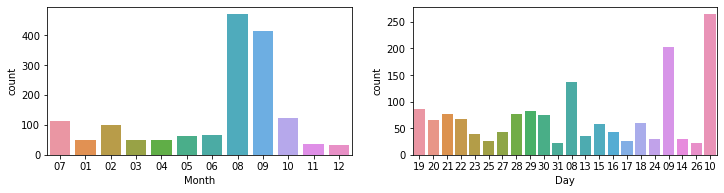

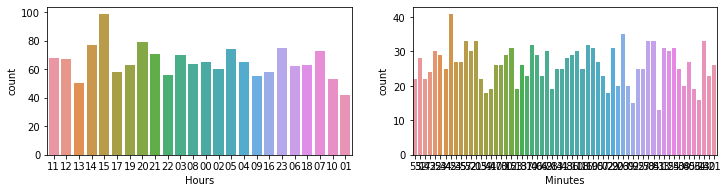

```python
###################################################
###################################################

def plot_count(date_time):
    i=1
    j=2
    plt.figure(figsize=(12,6))
    for col in data1_date_time.columns:
        plt.subplot(2,2,i)
        sns.countplot(x=data1_date_time[col])
        i+=1
        if i>j:
            i=1
            j+=1
            plt.show()
            plt.figure(figsize=(12,6))
###################################################
###################################################

def plot_kde(dataframe):
    i=1
    j=2
    plt.figure(figsize=(12,6))
    for col in dataframe.columns:
        plt.subplot(2,2,i)
        sns.kdeplot(x=dataframe[col])
        i+=1
        if i>j:
            i=1
            j+=1
            plt.show()
            plt.figure(figsize=(12,6))

###################################################
##################################################
plot_count(data1_date_time)
```

**Observations** :

We have to check if these have any correlation with our production, pass/fail state of a particular kind. First we have to check the peak days, peak months and have a countplot accordingly of the Pass/Fail Ratio.

```python
Month_grp=data1_date_time.groupby(["Month"])
Days_grp=data1_date_time.groupby(["Day"])

interested_months=("08","09")
interested_days=("08","09","10","25","26","31")
#############################################################
Month_interest_index={}
Days_interest_index={}
#############################################################
# Creating a dictionary object for indices to check out if the indices match out for in what way of Pass/Fail Ratio
for each in interested_months:
    #print(type(each))
    Month_interest_index.update({each:Month_grp.indices[each]})
##################################################################
# Creating a Dictionary object for indices to check out if the indices match out for in what way of Pass/Fail Ratio
for each in interested_days:
    Days_interest_index.update({each:Days_grp.indices[each]})
######################################################################
```

Let us now filter out how many of those indices match and interact.

```python
#######################################################################
######################################################################
# Function that is going to generate some statistics based on certain criteria.
def Statistics_for_Scenario(df_given,index_given):
    Out_statistics=[]
    for each_item in index_given:
        data_frame=data1.T[list(index_given[each_item])]
        data_frame=data_frame.T
        Total=data_frame.shape[0] #Total Entries within the
        pass_case=data_frame[data_frame["Pass/Fail"]==-1].shape[0] #No of pass cases in that particular category
        fail_case=data_frame[data_frame["Pass/Fail"]==1].shape[0] #No of fail cases in that particular category
        #print(each_item)
        Out_statistics.append([each_item,pass_case,fail_case,Total])
    return Out_statistics
########################################################################
########################################################################
Monthly_Statistics=Statistics_for_Scenario(data1,Month_grp.indices)
Day_Statistics=Statistics_for_Scenario(data1,Days_grp.indices)
```

```python
Monthly_Df=pd.DataFrame(Monthly_Statistics,columns=["Month","Pass","Fail","Total"])
Day_Df=pd.DataFrame(Day_Statistics,columns=["Day","Pass","Fail","Total"])
##############################################################################
```

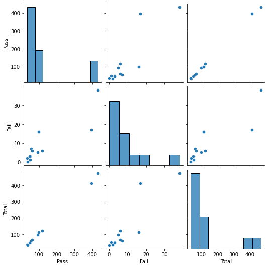

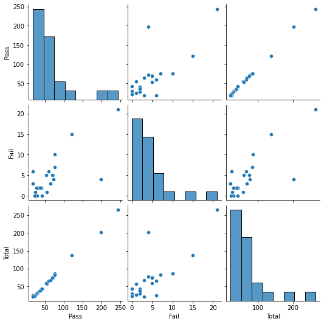

```python
sns.pairplot(Monthly_Df)
plt.show()
sns.pairplot(Day_Df)
```

```python
#Day_Df
```

```python
Day_Df["Fail_Ratio"]=Day_Df["Fail"]/Day_Df["Total"]
Monthly_Df["Fail_Ratio"]=Monthly_Df["Fail"]/Day_Df["Total"]
Day_Df["Pass_Ratio"]=Day_Df["Pass"]/Day_Df["Total"]
Monthly_Df["Pass_Ratio"]=Monthly_Df["Pass"]/Day_Df["Total"]
Day_Df["Proportion_Approx"]=Day_Df["Pass"]/Day_Df["Fail"]
Monthly_Df["Proportion_Approx"]=Monthly_Df["Pass"]/Day_Df["Fail"]
```

```python
Monthly_Df #Dataframe describing the Pass and Fail Ratio by Month
```

|  | Month | Pass | Fail | Total | Fail_Ratio | Pass_Ratio | Proportion_Approx |
| --- | --- | --- | --- | --- | --- | --- | --- |
| 0 | 01 | 48 | 3 | 51 | 0.021898 | 0.350365 | 3.200000 |
| 1 | 02 | 93 | 5 | 98 | 0.024752 | 0.460396 | 23.250000 |
| 2 | 03 | 49 | 1 | 50 | 0.003774 | 0.184906 | 2.333333 |
| 3 | 04 | 46 | 3 | 49 | 0.085714 | 1.314286 | 23.000000 |
| 4 | 05 | 55 | 7 | 62 | 0.233333 | 1.833333 | inf |
| 5 | 06 | 61 | 6 | 67 | 0.105263 | 1.070175 | 61.000000 |
| 6 | 07 | 98 | 16 | 114 | 0.372093 | 2.279070 | 49.000000 |
| 7 | 08 | 433 | 38 | 471 | 1.520000 | 17.320000 | 72.166667 |
| 8 | 09 | 396 | 17 | 413 | 0.288136 | 6.711864 | 79.200000 |
| 9 | 10 | 117 | 6 | 123 | 0.069767 | 1.360465 | 11.700000 |
| 10 | 11 | 33 | 2 | 35 | 0.030303 | 0.500000 | 5.500000 |
| 11 | 12 | 34 | 0 | 34 | 0.000000 | 0.441558 | 8.500000 |

```python
Day_Df #Dataframe describing the Pass and Fail Ratio by Day
```

|  | Day | Pass | Fail | Total | Fail_Ratio | Pass_Ratio | Proportion_Approx |
| --- | --- | --- | --- | --- | --- | --- | --- |
| 0 | 08 | 122 | 15 | 137 | 0.109489 | 0.890511 | 8.133333 |
| 1 | 09 | 198 | 4 | 202 | 0.019802 | 0.980198 | 49.500000 |
| 2 | 10 | 244 | 21 | 265 | 0.079245 | 0.920755 | 11.619048 |
| 3 | 13 | 33 | 2 | 35 | 0.057143 | 0.942857 | 16.500000 |
| 4 | 14 | 30 | 0 | 30 | 0.000000 | 1.000000 | inf |
| 5 | 15 | 56 | 1 | 57 | 0.017544 | 0.982456 | 56.000000 |
| 6 | 16 | 41 | 2 | 43 | 0.046512 | 0.953488 | 20.500000 |
| 7 | 17 | 19 | 6 | 25 | 0.240000 | 0.760000 | 3.166667 |
| 8 | 18 | 54 | 5 | 59 | 0.084746 | 0.915254 | 10.800000 |
| 9 | 19 | 76 | 10 | 86 | 0.116279 | 0.883721 | 7.600000 |
| 10 | 20 | 60 | 6 | 66 | 0.090909 | 0.909091 | 10.000000 |
| 11 | 21 | 73 | 4 | 77 | 0.051948 | 0.948052 | 18.250000 |
| 12 | 22 | 65 | 3 | 68 | 0.044118 | 0.955882 | 21.666667 |
| 13 | 23 | 37 | 2 | 39 | 0.051282 | 0.948718 | 18.500000 |
| 14 | 24 | 28 | 2 | 30 | 0.066667 | 0.933333 | 14.000000 |
| 15 | 25 | 25 | 1 | 26 | 0.038462 | 0.961538 | 25.000000 |
| 16 | 26 | 23 | 0 | 23 | 0.000000 | 1.000000 | inf |
| 17 | 27 | 43 | 0 | 43 | 0.000000 | 1.000000 | inf |
| 18 | 28 | 71 | 5 | 76 | 0.065789 | 0.934211 | 14.200000 |
| 19 | 29 | 76 | 7 | 83 | 0.084337 | 0.915663 | 10.857143 |
| 20 | 30 | 70 | 5 | 75 | 0.066667 | 0.933333 | 14.000000 |
| 21 | 31 | 19 | 3 | 22 | 0.136364 | 0.863636 | 6.333333 |

**Remarks** : Even though there seems to be some interesting patterns noted here and there, we don't need to go too deep into this. It seems to be legitimate and the data mining can't happen like this.

**Exploring the Dimension of Polarity and Flip**

It can be easily assumed that anamolies exist, usually in the form of flipping the polarity of the voltages and if any of these sensors happen to be something of the likes of LVDT (Linear Variable Differential Transformers), they might detect reverse polarity voltage, usually noted as negative numbers, and sometimes they create interesting patterns.

Keeping that in mind, this dimensino is explored.

**Please Note** : We could have done all this on a much simpler note with the data description itself, but that doesn't create the amount of detail required for such a detailed analysis. Hence, the following was retained after trail and error.

```python
positive_number_columns=data1_wo_[data1_wo_>0].count()
negative_number_columns=data1_wo_[data1_wo_<0].count()
zero_number_columns=data1_wo_[data1_wo_==0].count()
#####################################################################
#Polarity of the Column
positive_negative_judgements=pd.DataFrame([range(data1_wo_.shape[1]),positive_number_columns,negative_number_columns,zero_number_columns],index=["Sensor","positives","negatives","zeros"]).T
#####################################################################
positive_negative_judgements
```

|  | Sensor | positives | negatives | zeros |
| --- | --- | --- | --- | --- |
| 0 | 0 | 1561 | 0 | 0 |
| 1 | 1 | 1560 | 0 | 0 |
| 2 | 2 | 1553 | 0 | 0 |
| 3 | 3 | 1552 | 0 | 1 |
| 4 | 4 | 1553 | 0 | 0 |
| ... | ... | ... | ... | ... |
| 585 | 585 | 1566 | 0 | 0 |
| 586 | 586 | 1524 | 42 | 0 |
| 587 | 587 | 1566 | 0 | 0 |
| 588 | 588 | 1566 | 0 | 0 |
| 589 | 589 | 1534 | 0 | 32 |

590 rows × 4 columns

This gives the clear picture on which sensors is having how many recorded values of what values.

We could have gone with isnull() function or something similar, but that doesn't paint a complete picture, and the reading of a sensor being 0 is not to be mistaken as a no reading or missing reading. The reading itself might actually be of tremendous value indicating abnormality or normality.

**Note** : Here sp : some positive nn : no negative np : no positive sn : some negative

```python
only_zero_values_sensors_df=data1.loc[positive_negative_judgements[(positive_negative_judgements["negatives"]==0) & (positive_negative_judgements["positives"]==0)].index]
only_positive_values_sensors_df=data1.loc[positive_negative_judgements[(positive_negative_judgements["negatives"]==0) & (positive_negative_judgements["zeros"]==0)].index]
only_negative_values_sensors_df=data1.loc[positive_negative_judgements[(positive_negative_judgements["positives"]==0) & (positive_negative_judgements["zeros"]==0)].index]
some_zero_sp_nn_df=data1.loc[positive_negative_judgements[(positive_negative_judgements["negatives"]==0) & (positive_negative_judgements["positives"]>=0)].index]
some_zero_sn_np_df=data1.loc[positive_negative_judgements[(positive_negative_judgements["negatives"]>=0) & (positive_negative_judgements["negatives"]==0)].index]
```

```python
only_negative_values_sensors_df #Interesting dataframe
```

|  | Time | 0 | 1 | 2 | 3 | 4 | 5 | 6 | 7 | 8 | ... | 581 | 582 | 583 | 584 | 585 | 586 | 587 | 588 | 589 | Pass/Fail |
| --- | --- | --- | --- | --- | --- | --- | --- | --- | --- | --- | --- | --- | --- | --- | --- | --- | --- | --- | --- | --- | --- |

0 rows × 592 columns

The above dataframe has no values indicating that there are no sensors that give only negative values or in other words faulty sensors.

```python
stats_to_see={"only_zero_values_sensors":only_zero_values_sensors_df,
              "only_positive_values_sensors":only_positive_values_sensors_df,
              "only_negative_values_sensors":only_negative_values_sensors_df,
              "some_zero_sp_nn":some_zero_sp_nn_df,
              "some_zero_sn_np":some_zero_sn_np_df}
```

```python
only_negative_values_sensors_df.shape[0] # printing out the sensors that only produce negative values
```

```
0
```

**Observations**:

```python
#Function that returns statistics for analysis of various categories.
##########################################################
############################################################
def values_statistics(dataframe,column,values):
    data=[]
    #print(column)
    for each in values:
        #print(dataframe)
        #print(len(dataframe[dataframe[column]==values[each]].index))
        #print(values[each])
        data.append(list(dataframe[dataframe[column]==each].index))
        #print(each)
        #print(data)
    return data
########################################################3
########################################################
stats={} # We use this variable name again much later. BEWARE
for value in stats_to_see:
    stats.update({value : values_statistics(stats_to_see[value],column="Pass/Fail",values=[-1,1])})
#####################################################
```

```python
stats=pd.DataFrame(stats,index=["Pass","Fail"])
#stirr=stats.copy()
#print(stats)
###########################################################
###########################################################
def append_data_within(dataframe,function=len):
    k=[]
    for row in dataframe.index:
        temp=[]
        for col in dataframe.columns:
            temp.append(function(dataframe[col][row]))
        #temp.append(temp[0]+temp[1])
        k.append(temp)
    return k
#############################################################
#############################################################
stats.append(pd.DataFrame(append_data_within(stats),columns=list(stats.columns),index=["Total_no_Pass","Total_no_Fail"]))
```

|  | only_zero_values_sensors | only_positive_values_sensors | only_negative_values_sensors | some_zero_sp_nn | some_zero_sn_np |
| --- | --- | --- | --- | --- | --- |
| Pass | [13, 52, 97, 141, 149, 178, 179, 190, 191, 192... | [0, 1, 4, 5, 6, 8, 12, 15, 16, 17, 18, 19, 20,... | [] | [0, 1, 3, 4, 5, 6, 7, 8, 12, 13, 15, 16, 17, 1... | [0, 1, 3, 4, 5, 6, 7, 8, 12, 13, 15, 16, 17, 1... |
| Fail | [186, 189, 231, 235, 236, 240, 241, 243, 326, ... | [2, 11, 14, 38, 40, 45, 48, 49, 50, 57, 58, 62... | [] | [2, 11, 14, 38, 40, 45, 48, 49, 50, 57, 58, 62... | [2, 11, 14, 38, 40, 45, 48, 49, 50, 57, 58, 62... |
| Total_no_Pass | 100 | 322 | 0 | 495 | 495 |
| Total_no_Fail | 12 | 45 | 0 | 59 | 59 |

Now carefully observe the data given above. The Total number of sensors output which is putting out Zero values into some data points and are contributing to the pass case and fail case scenario appropriately.

**Please Note**

Note that zero value of the sensor doesn't mean that sensor is not reading the value. It simply means that the change observed might be zero, or that the sensor itself might be faulty, or that production might have zero value for that. It depends completely upon the situation.

**Observations and Notes** :

There are 590 sensors in all. So, that means the above serves a good direction to check out which sensors might be crucial or important in deciding/swinging the total output in any one particular direction. Depending upon that we can decide what type of outlier treatement is needed for that particular type of sensor readings.

For e.g. if the sensors are sending positive values all the time in Pass case, and has suddenly went negative and is causing the Fail case scenario, then those sensor readings are crucial and might be the most important deciding factor. Based on that we can program our model to ignore some set of sensors within certain amount of variations, and/or take small variations within a particular set of sensors very seriously before the entire production takes a hit.

Based on that idea, we can do some analysis here and check which ones have direct link to the Pass or Fail case scenario, and even generate maximum variations within the data.

We can go into more detail and check for threshold values within these sensors so that particular threshold values crossing, either in positive value mode or negative value mode, contribute towards the Pass Case Scenario or Fail Case Scenario of the particular dataset. But that will be dealt with later on after identifying some key contributors and sensors of the data.

**Some Notes** :

We can now go ahead and check if

1. Those sensors that produced some zero and some positive values have suddenly turned negative/zero and by turning how many of them contributed to Pass case Scenario and How many of them continued to be in Fail case Scenario.
2. Those Sensors that produced some zero and some negative values have suddenly turned positive/zero and by turning so how many of them contributed to Fail case Scenario and how many of them continued in the pass case Scenario.

```python
positive_sensors_pass=stats["some_zero_sp_nn"]["Pass"] #Sensors having positive values and contribute to Pass case
negative_sensors_pass=stats["some_zero_sn_np"]["Pass"] #Sensors having negative values and contribute to Pass case
positive_sensors_fail=stats["some_zero_sp_nn"]["Fail"] #Sensors having positivie values and contibute to Fail Case
negative_sensors_fail=stats["some_zero_sn_np"]["Fail"] #Sensors having negative values and contribute to Fail Case
```

```python
#Checking if any of them are in the other, i.e. if they flipped their status.
flipped_sensors=[]
################################################################3
for sensor in positive_sensors_pass:
    if sensor in negative_sensors_fail:
        flipped_sensors.append(sensor)
for sensor in negative_sensors_pass:
    if sensor in positive_sensors_fail:
        flipped_sensors.append(sensor)
################################################################
print("The Sensors which have flipped their values to indicate the change case thereby indicating the change in Suceess rate is",len(flipped_sensors))
```

```
The Sensors which have flipped their values to indicate the change case thereby indicating the change in Suceess rate is 0
```

**Conclusions so far** :

```python
plot_var=data1_target_wo.sum()-data1_notarget_wo.sum()
#Differences in summation of the total sensor values between both cases.
plot_var
```

```
0     -4.079996e+06
1     -3.379544e+06
2     -2.959758e+06
3     -1.886570e+06
4     -6.246853e+03
           ...
585   -4.152065e+03
586   -2.910050e+01
587   -2.212990e+01
588   -7.105100e+00
589   -1.355462e+05
Length: 590, dtype: float64
```

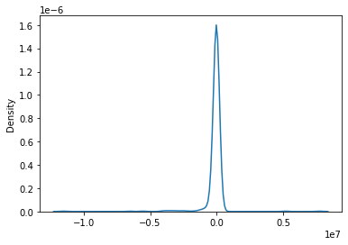

```python
sns.kdeplot(plot_var)
#difference in the total summation of the sensor values
```

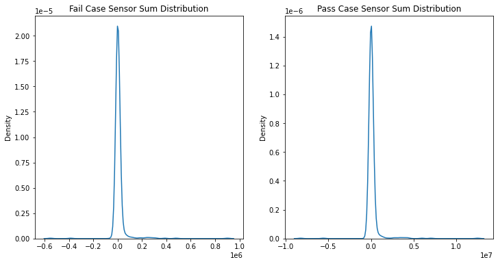

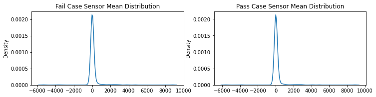

```python
plt.figure(figsize=(12,6))
plt.subplot(1,2,1)
sns.kdeplot(data1_target_wo.sum()) #Total Summation of the sensor values in fail case scenario
plt.title("Fail Case Sensor Sum Distribution")
plt.subplot(1,2,2)
sns.kdeplot(data1_notarget_wo.sum()) # Total Summation of the sensor values in the Pass case Scenario
plt.title("Pass Case Sensor Sum Distribution")
plt.show()
plt.figure(figsize=(12,6))
plt.subplot(2,2,1)
sns.kdeplot(data1_target_wo.mean())
plt.title("Fail Case Sensor Mean Distribution")
plt.subplot(2,2,2)
sns.kdeplot(data1_notarget_wo.mean())
plt.title("Pass Case Sensor Mean Distribution")
plt.show()
```

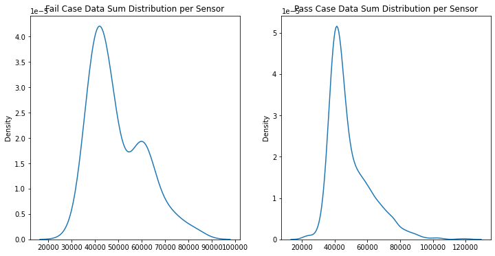

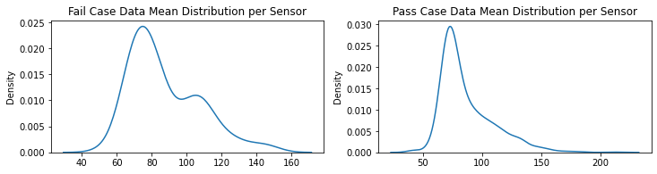

```python
plt.figure(figsize=(12,6))
plt.subplot(1,2,1)
sns.kdeplot(data1_target_wo.T.sum()) #Total Summation of the sensor values in fail case scenario
plt.title("Fail Case Data Sum Distribution per Sensor")
plt.subplot(1,2,2)
sns.kdeplot(data1_notarget_wo.T.sum()) # Total Summation of the sensor values in the Pass case Scenario
plt.title("Pass Case Data Sum Distribution per Sensor")
plt.show()
plt.figure(figsize=(12,6))
plt.subplot(2,2,1)
sns.kdeplot(data1_target_wo.T.mean())
plt.title("Fail Case Data Mean Distribution per Sensor")
plt.subplot(2,2,2)
sns.kdeplot(data1_notarget_wo.T.mean())
plt.title("Pass Case Data Mean Distribution per Sensor")
plt.show()
```

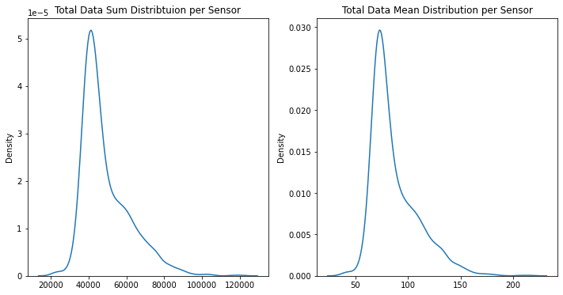

```python
plt.figure(figsize=(12,6))
plt.subplot(1,2,1)
sns.kdeplot(data1_wo_.T.sum())
plt.title("Total Data Sum Distribtuion per Sensor")
plt.subplot(1,2,2)
sns.kdeplot(data1_wo_.T.mean())
plt.title("Total Data Mean Distribution per Sensor")

plt.show()
```

**Observations** :

It seems to be seen that there is not much difference between the two i.e. the mean, the sum and the difference between the two outcomes of the manufacturing process (observed in the above pictures by sharp peaks around '0'). The conclusively decides that, there is some element or value within the Sensor (a particular sensor perhaps), that is counterbalancing the anamoly detection through some kind of mechanism, that might have negative correlation with one of the sensors and is contributing towards the clean sweep of the anamolies. We might need to find out exactly what sensors those are. If we are successful, then we can eliminate the junk of the columns through some PCA or something, and then retain those special group of sensors, that are key sensors who decide the fate of the manufacturing.

Also clustering is no to going to save the day for us because most of the values for all the sensors seems tobe averaging to zero. So, we will end up with one unusually big cluster and small bunch of clusters and random cases of outliers in each, for each of the cases.

Only sense of the data here is that Sum distribution per sensor, and that is balanced by mean because there are more Pass cases than fail cases.

Let us leave this fascinating idea aside and go for the covariance and correlation relations.

**Correlation and Covariance**

These are the dimenions explored here for interesting patterins and all.

```python
###########################################################
#Correlation of the particular dataframes
data1_wo_corr=data1_wo.corr()
data1_target_wo_corr=data1_target_wo.corr()
data1_notarget_wo_corr=data1_notarget_wo.corr()
###########################################################
#Covariance of the particular dataframes
data1_wo_cov=data1_wo.cov()
data1_target_wo_cov=data1_target_wo.cov()
data1_notarget_wo_cov=data1_notarget_wo.cov()
###########################################################
```

**Caution**

Attempts have been made to see this appropriately within the Jupyter itself, which didn't prove fruitful. So, they are simply commented out. Please be aware of the computation power it is going to take and the time required, to actually plot those data and proceed, if you choose to.

```python
plt.figure(figsize=(20,20))
#sns.heatmap(data1_wo_corr,annot=True)
plt.show()
```

```python
plt.figure(figsize=(20,20))
#sns.heatmap(data1_wo_cov,annot=True)
plt.show()
```

```python
data1_wo_corr.describe()
```

|  | 0 | 1 | 2 | 3 | 4 | 5 | 6 | 7 | 8 | 9 | ... | 581 | 582 | 583 | 584 | 585 | 586 | 587 | 588 | 589 | Pass/Fail |
| --- | --- | --- | --- | --- | --- | --- | --- | --- | --- | --- | --- | --- | --- | --- | --- | --- | --- | --- | --- | --- | --- |
| count | 475.000000 | 475.000000 | 475.000000 | 475.000000 | 475.000000 | 0.0 | 475.000000 | 475.000000 | 475.000000 | 475.000000 | ... | 469.000000 | 475.000000 | 475.000000 | 475.000000 | 475.000000 | 475.000000 | 475.000000 | 475.000000 | 475.000000 | 475.000000 |
| mean | -0.001750 | 0.004610 | 0.002973 | -0.005876 | 0.010665 | NaN | 0.001876 | -0.010828 | 0.004629 | 0.001913 | ... | 0.012645 | 0.000920 | 0.009168 | 0.009203 | 0.009141 | -0.004753 | 0.013452 | 0.013208 | 0.015580 | 0.011686 |
| std | 0.062152 | 0.056844 | 0.065455 | 0.081966 | 0.117521 | NaN | 0.083754 | 0.113732 | 0.068882 | 0.059915 | ... | 0.097121 | 0.062679 | 0.085096 | 0.085118 | 0.085172 | 0.084659 | 0.101218 | 0.100460 | 0.091254 | 0.060973 |
| min | -0.150995 | -0.197034 | -0.273970 | -0.685835 | -0.916410 | NaN | -0.685835 | -0.916723 | -0.177732 | -0.152133 | ... | -0.475397 | -0.197502 | -0.190090 | -0.197502 | -0.197363 | -0.486559 | -0.149805 | -0.139347 | -0.486559 | -0.113950 |
| 25% | -0.025045 | -0.014964 | -0.021432 | -0.031923 | -0.011639 | NaN | -0.029345 | -0.019225 | -0.028579 | -0.024565 | ... | -0.027072 | -0.026471 | -0.011408 | -0.010985 | -0.011057 | -0.032730 | -0.019048 | -0.017807 | -0.017872 | -0.014868 |
| 50% | -0.007373 | 0.002646 | 0.000058 | -0.003690 | -0.001240 | NaN | 0.005600 | 0.001641 | 0.006734 | -0.002725 | ... | -0.001711 | -0.000023 | 0.000696 | 0.000351 | 0.000471 | -0.009699 | 0.000653 | 0.001340 | 0.012134 | 0.005066 |
| 75% | 0.015605 | 0.021420 | 0.018824 | 0.018823 | 0.010474 | NaN | 0.034028 | 0.015973 | 0.032324 | 0.022435 | ... | 0.040730 | 0.022267 | 0.015108 | 0.015978 | 0.014802 | 0.016194 | 0.024809 | 0.023334 | 0.039519 | 0.035019 |
| max | 1.000000 | 1.000000 | 1.000000 | 1.000000 | 1.000000 | NaN | 1.000000 | 1.000000 | 1.000000 | 1.000000 | ... | 1.000000 | 1.000000 | 1.000000 | 1.000000 | 1.000000 | 1.000000 | 1.000000 | 1.000000 | 1.000000 | 1.000000 |

8 rows × 591 columns

```python
data1_wo_cov.describe()
```

|  | 0 | 1 | 2 | 3 | 4 | 5 | 6 | 7 | 8 | 9 | ... | 581 | 582 | 583 | 584 | 585 | 586 | 587 | 588 | 589 | Pass/Fail |
| --- | --- | --- | --- | --- | --- | --- | --- | --- | --- | --- | --- | --- | --- | --- | --- | --- | --- | --- | --- | --- | --- |
| count | 591.000000 | 591.000000 | 591.000000 | 591.000000 | 591.000000 | 591.0 | 591.000000 | 591.000000 | 591.000000 | 591.000000 | ... | 591.000000 | 591.000000 | 591.000000 | 591.000000 | 591.000000 | 591.000000 | 591.000000 | 591.000000 | 591.000000 | 591.000000 |
| mean | 74.135334 | 28.680801 | -24.268470 | 393.188282 | 45.473017 | 0.0 | -12.219426 | 0.002907 | -0.012161 | -0.010624 | ... | 122.772013 | 0.000933 | -0.007062 | -0.001716 | -1.464843 | 0.003700 | 0.000669 | -0.000039 | 16.474841 | 0.103306 |
| std | 1461.459038 | 908.623322 | 588.023444 | 10417.306574 | 1304.425166 | 0.0 | 196.793581 | 0.120218 | 0.882214 | 0.154283 | ... | 1126.696047 | 0.021929 | 0.126596 | 0.030086 | 26.316906 | 0.183862 | 0.073384 | 0.019254 | 1152.429543 | 3.744195 |
| min | -4755.221206 | -14060.037256 | -11509.714374 | -63925.092561 | -6497.909764 | 0.0 | -3713.605033 | -1.578590 | -15.135268 | -2.385491 | ... | -4387.560318 | -0.233537 | -2.007152 | -0.443586 | -416.225187 | -0.926605 | -1.284103 | -0.278271 | -18577.887611 | -41.214321 |
| 25% | -0.922501 | -0.123092 | -0.071478 | -2.995552 | -0.230688 | 0.0 | -0.017676 | -0.000012 | -0.000327 | -0.000177 | ... | -0.455050 | -0.000019 | -0.000025 | -0.000005 | -0.005295 | -0.000474 | -0.000027 | -0.000013 | -0.065611 | -0.000971 |
| 50% | 0.000000 | 0.000000 | 0.000000 | 0.000000 | 0.000000 | 0.0 | 0.000000 | 0.000000 | 0.000000 | 0.000000 | ... | 0.000000 | 0.000000 | 0.000000 | 0.000000 | 0.000000 | 0.000000 | 0.000000 | 0.000000 | 0.000000 | 0.000000 |
| 75% | 0.048847 | 0.281090 | 0.159178 | 1.965296 | 0.058390 | 0.0 | 0.068102 | 0.000049 | 0.000662 | 0.000022 | ... | 0.346644 | 0.000007 | 0.000072 | 0.000014 | 0.014767 | 0.000005 | 0.000037 | 0.000009 | 2.708253 | 0.003295 |
| max | 30692.052097 | 12967.141414 | 3896.827106 | 195091.505178 | 28567.158465 | 0.0 | 1046.012990 | 1.811925 | 7.625891 | 0.633519 | ... | 16275.102227 | 0.317540 | 0.974909 | 0.220505 | 203.668784 | 3.519607 | 0.586249 | 0.196355 | 8815.692532 | 38.148219 |

8 rows × 591 columns

```python
data1_wo_corr[(data1_wo_corr["Pass/Fail"]<1) & (data1_wo_corr["Pass/Fail"]>0.2)]
```

|  | 0 | 1 | 2 | 3 | 4 | 5 | 6 | 7 | 8 | 9 | ... | 581 | 582 | 583 | 584 | 585 | 586 | 587 | 588 | 589 | Pass/Fail |
| --- | --- | --- | --- | --- | --- | --- | --- | --- | --- | --- | --- | --- | --- | --- | --- | --- | --- | --- | --- | --- | --- |

0 rows × 591 columns

Looks like Covariance and Correlation mechanisms are taking us nowhere. It is really tough to go anywhere from here. So, we will step up to take some features and do some calculations and use some smart techniques to figure out which values we should use to replace in NaN places.

**Unfilled Data (NaN) Exploration**

It becomes extremely important with regards to what data we are going to fill for the missing data in our dataframe because sometimes those missing data might speak. Sometimes, filling with wrong type of data might cause wrong learning outcomes.

Some ideas to explored are :

1. If a data entry point is missing for a sensor, does it mean anything for the sensor and the final outcome ?
2. In what way is the corresponding sensor values distributed Normal, multi-model, discrete?
3. If so, what should our choice be depending upon the choice of distribution in the particular sensor columns.
4. Does missing value in one sensor affect missing of some other sensor value ? Do they have any covariance at all ?
5. If a sensor has missing values, then does the proportion of missing values, the type of distribution in the sensor column, and does the same scenario change for the other cases (is there any deviation from the exhibited pattern, after we are able to find out the pattern)

There are a lot of other ideas, we explore as we go. But, they key focus would always be towards finding a strategy to fill in the missing values, instead of pattern recognition or just a blind filling with mean or with some other pattern. I strongly believe we should have separate strategies to fill in both pass case and fail case scenarios to retain the essence of the data and don't become self-contradictory.

In the process we have taken some strange turns, but, it is by no means exhaustive. Infact, it comes to abrupt end.

```python
data1_target_wo_desc=data1_target_wo.describe()
data1_target_wo_desc #Fail case scenario data entries
```

|  | 0 | 1 | 2 | 3 | 4 | 5 | 6 | 7 | 8 | 9 | ... | 580 | 581 | 582 | 583 | 584 | 585 | 586 | 587 | 588 | 589 |
| --- | --- | --- | --- | --- | --- | --- | --- | --- | --- | --- | --- | --- | --- | --- | --- | --- | --- | --- | --- | --- | --- |
| count | 104.000000 | 103.000000 | 104.000000 | 104.000000 | 104.000000 | 104.0 | 104.000000 | 104.000000 | 104.000000 | 104.000000 | ... | 45.000000 | 45.000000 | 104.000000 | 104.000000 | 104.000000 | 104.000000 | 104.000000 | 104.000000 | 104.000000 | 104.000000 |
| mean | 3007.526250 | 2495.059709 | 2200.441877 | 1355.781435 | 1.303405 | 100.0 | 101.490972 | 0.122257 | 1.470619 | -0.002608 | ... | 0.005700 | 91.459929 | 0.500696 | 0.015703 | 0.003922 | 3.135344 | 0.021651 | 0.017643 | 0.005618 | 98.736237 |
| std | 88.409688 | 71.316362 | 31.302444 | 341.306204 | 0.336390 | 0.0 | 4.995910 | 0.001902 | 0.059834 | 0.013726 | ... | 0.002918 | 61.717029 | 0.003849 | 0.007046 | 0.001400 | 1.408797 | 0.011422 | 0.008563 | 0.002715 | 79.922392 |
| min | 2848.460000 | 2286.250000 | 2138.877800 | 899.948800 | 0.681500 | 100.0 | 87.278900 | 0.116000 | 1.342100 | -0.034300 | ... | 0.001600 | 0.000000 | 0.491500 | 0.008700 | 0.002200 | 1.746900 | -0.003400 | 0.004200 | 0.001600 | 0.000000 |
| 25% | 2946.120000 | 2457.785000 | 2173.480575 | 1069.645950 | 1.044875 | 100.0 | 99.113300 | 0.121100 | 1.431675 | -0.009650 | ... | 0.003700 | 53.746000 | 0.498350 | 0.011500 | 0.003000 | 2.285700 | 0.015225 | 0.011200 | 0.003700 | 45.619225 |
| 50% | 2989.315000 | 2500.850000 | 2196.688900 | 1281.536800 | 1.305650 | 100.0 | 101.638900 | 0.122200 | 1.468500 | -0.001800 | ... | 0.005400 | 75.507700 | 0.501000 | 0.013800 | 0.003700 | 2.759100 | 0.020550 | 0.016800 | 0.005300 | 76.058550 |
| 75% | 3053.280000 | 2532.010000 | 2218.936075 | 1558.445325 | 1.511100 | 100.0 | 104.113625 | 0.123700 | 1.510125 | 0.005100 | ... | 0.007100 | 109.427300 | 0.503100 | 0.017025 | 0.004200 | 3.392675 | 0.028300 | 0.022000 | 0.007100 | 120.742150 |
| max | 3266.550000 | 2714.300000 | 2315.266700 | 2360.132500 | 2.421000 | 100.0 | 119.354400 | 0.127600 | 1.610700 | 0.027900 | ... | 0.015000 | 289.923400 | 0.508800 | 0.046000 | 0.009700 | 9.167700 | 0.058400 | 0.055600 | 0.015000 | 474.081200 |

8 rows × 590 columns

```python
data1_notarget_wo_desc=data1_notarget_wo.describe()
data1_notarget_wo_desc #Pass case scenario data entries
```

|  | 0 | 1 | 2 | 3 | 4 | 5 | 6 | 7 | 8 | 9 | ... | 580 | 581 | 582 | 583 | 584 | 585 | 586 | 587 | 588 | 589 |
| --- | --- | --- | --- | --- | --- | --- | --- | --- | --- | --- | --- | --- | --- | --- | --- | --- | --- | --- | --- | --- | --- |
| count | 1457.000000 | 1457.000000 | 1449.000000 | 1449.000000 | 1449.000000 | 1449.0 | 1449.000000 | 1454.000000 | 1461.000000 | 1461.000000 | ... | 573.000000 | 573.000000 | 1462.000000 | 1462.000000 | 1462.000000 | 1462.000000 | 1462.000000 | 1462.000000 | 1462.000000 | 1462.000000 |
| mean | 3014.947316 | 2495.906115 | 2200.554886 | 1399.290292 | 4.404698 | 100.0 | 101.085773 | 0.121790 | 1.462309 | -0.000715 | ... | 0.005372 | 98.442837 | 0.500053 | 0.015290 | 0.003841 | 3.063023 | 0.021445 | 0.016392 | 0.005260 | 99.736495 |
| std | 72.461809 | 81.033476 | 29.391944 | 447.984948 | 58.338675 | 0.0 | 6.317480 | 0.009262 | 0.074783 | 0.015207 | ... | 0.003132 | 89.252336 | 0.003368 | 0.017682 | 0.003833 | 3.684206 | 0.012426 | 0.008822 | 0.002877 | 94.830589 |
| min | 2743.240000 | 2158.750000 | 2060.660000 | 0.000000 | 0.681500 | 100.0 | 82.131100 | 0.000000 | 1.191000 | -0.053400 | ... | 0.001000 | 0.000000 | 0.477800 | 0.006000 | 0.001700 | 1.197500 | -0.016900 | 0.003200 | 0.001000 | 0.000000 |
| 25% | 2968.780000 | 2452.150000 | 2181.188900 | 1081.875800 | 1.016000 | 100.0 | 97.777800 | 0.121100 | 1.410300 | -0.010800 | ... | 0.003400 | 46.101600 | 0.497900 | 0.011600 | 0.003100 | 2.311850 | 0.013400 | 0.010600 | 0.003300 | 44.316250 |
| 50% | 3012.680000 | 2499.150000 | 2201.066700 | 1285.214400 | 1.316800 | 100.0 | 101.512200 | 0.122400 | 1.461100 | -0.001300 | ... | 0.004600 | 72.023000 | 0.500100 | 0.013800 | 0.003600 | 2.757650 | 0.020500 | 0.014800 | 0.004600 | 71.676650 |
| 75% | 3057.030000 | 2539.460000 | 2218.055500 | 1591.223500 | 1.529100 | 100.0 | 104.586700 | 0.123800 | 1.517200 | 0.008600 | ... | 0.006400 | 117.094500 | 0.502300 | 0.016400 | 0.004100 | 3.281525 | 0.027500 | 0.020000 | 0.006400 | 114.749700 |
| max | 3356.350000 | 2846.440000 | 2315.266700 | 3715.041700 | 1114.536600 | 100.0 | 129.252200 | 0.128600 | 1.656400 | 0.074900 | ... | 0.028600 | 737.304800 | 0.509800 | 0.476600 | 0.104500 | 99.303200 | 0.102800 | 0.079900 | 0.028600 | 737.304800 |

8 rows × 590 columns

**Strategic Plan** The plan will be to check how many of the sensors have a maximum output that is completely outside certain standard deviations away. So, depending on that we might make sure that we replace those values with Maximum values or 75%values.

But first, let us check check in both failure case and pass case scenario whether if there are any sensors that produce similar pattern changes.

First to check is to see which sensors produce 0 standard deviation, meaning that those sensors have no change at all.

```python
data1_target_wo_std=data1_target_wo.T[data1_target_wo_desc.T["std"]==0]
data1_notarget_wo_std=data1_notarget_wo.T[data1_notarget_wo_desc.T["std"]==0]
```

```python
data1_target_wo_std #Sensors showing no change in Fail Case
```

|  | 2 | 10 | 11 | 14 | 23 | 38 | 40 | 45 | 48 | 49 | ... | 1329 | 1342 | 1343 | 1363 | 1364 | 1365 | 1400 | 1438 | 1443 | 1519 |
| --- | --- | --- | --- | --- | --- | --- | --- | --- | --- | --- | --- | --- | --- | --- | --- | --- | --- | --- | --- | --- | --- |
| 5 | 100.0 | 100.0 | 100.0 | 100.0 | 100.0 | 100.0 | 100.0 | 100.0 | 100.0 | 100.0 | ... | 100.0 | 100.0 | 100.0 | 100.0 | 100.0 | 100.0 | 100.0 | 100.0 | 100.0 | 100.0 |
| 13 | 0.0 | 0.0 | 0.0 | 0.0 | 0.0 | 0.0 | 0.0 | 0.0 | 0.0 | 0.0 | ... | 0.0 | 0.0 | 0.0 | 0.0 | 0.0 | 0.0 | 0.0 | 0.0 | 0.0 | 0.0 |
| 42 | 70.0 | 70.0 | 70.0 | 70.0 | 70.0 | 70.0 | 70.0 | 70.0 | 70.0 | 70.0 | ... | 70.0 | 70.0 | 70.0 | 70.0 | 70.0 | 70.0 | 70.0 | 70.0 | 70.0 | 70.0 |
| 49 | 1.0 | 1.0 | 1.0 | 1.0 | 1.0 | 1.0 | 1.0 | 1.0 | 1.0 | 1.0 | ... | 1.0 | 1.0 | 1.0 | 1.0 | 1.0 | 1.0 | 1.0 | 1.0 | 1.0 | 1.0 |
| 52 | 0.0 | 0.0 | 0.0 | 0.0 | 0.0 | 0.0 | 0.0 | 0.0 | 0.0 | 0.0 | ... | 0.0 | 0.0 | 0.0 | 0.0 | 0.0 | 0.0 | 0.0 | 0.0 | 0.0 | 0.0 |
| ... | ... | ... | ... | ... | ... | ... | ... | ... | ... | ... | ... | ... | ... | ... | ... | ... | ... | ... | ... | ... | ... |
| 534 | 0.0 | 0.0 | 0.0 | 0.0 | 0.0 | 0.0 | 0.0 | 0.0 | 0.0 | 0.0 | ... | 0.0 | 0.0 | 0.0 | 0.0 | 0.0 | 0.0 | 0.0 | 0.0 | 0.0 | 0.0 |
| 535 | 0.0 | 0.0 | 0.0 | 0.0 | 0.0 | 0.0 | 0.0 | 0.0 | 0.0 | 0.0 | ... | 0.0 | 0.0 | 0.0 | 0.0 | 0.0 | 0.0 | 0.0 | 0.0 | 0.0 | 0.0 |
| 536 | 0.0 | 0.0 | 0.0 | 0.0 | 0.0 | 0.0 | 0.0 | 0.0 | 0.0 | 0.0 | ... | 0.0 | 0.0 | 0.0 | 0.0 | 0.0 | 0.0 | 0.0 | 0.0 | 0.0 | 0.0 |
| 537 | 0.0 | 0.0 | 0.0 | 0.0 | 0.0 | 0.0 | 0.0 | 0.0 | 0.0 | 0.0 | ... | 0.0 | 0.0 | 0.0 | 0.0 | 0.0 | 0.0 | 0.0 | 0.0 | 0.0 | 0.0 |
| 538 | 0.0 | 0.0 | 0.0 | 0.0 | 0.0 | 0.0 | 0.0 | 0.0 | 0.0 | 0.0 | ... | 0.0 | 0.0 | 0.0 | 0.0 | 0.0 | 0.0 | 0.0 | 0.0 | 0.0 | 0.0 |

122 rows × 104 columns

```python
data1_notarget_wo_std #Sensors showing no change in Pass case.
```

|  | 0 | 1 | 3 | 4 | 5 | 6 | 7 | 8 | 9 | 12 | ... | 1557 | 1558 | 1559 | 1560 | 1561 | 1562 | 1563 | 1564 | 1565 | 1566 |
| --- | --- | --- | --- | --- | --- | --- | --- | --- | --- | --- | --- | --- | --- | --- | --- | --- | --- | --- | --- | --- | --- |
| 5 | 100.0 | 100.0 | 100.0 | 100.0 | 100.0 | 100.0 | 100.0 | 100.0 | 100.0 | 100.0 | ... | 100.0 | 100.0 | 100.0 | 100.0 | 100.0 | 100.0 | 100.0 | 100.0 | 100.0 | 100.0 |
| 13 | 0.0 | 0.0 | 0.0 | 0.0 | 0.0 | 0.0 | 0.0 | 0.0 | 0.0 | 0.0 | ... | 0.0 | 0.0 | 0.0 | 0.0 | NaN | 0.0 | 0.0 | NaN | 0.0 | NaN |
| 42 | 70.0 | 70.0 | 70.0 | 70.0 | 70.0 | 70.0 | 70.0 | 70.0 | 70.0 | 70.0 | ... | 70.0 | 70.0 | 70.0 | 70.0 | 70.0 | 70.0 | 70.0 | 70.0 | 70.0 | 70.0 |
| 49 | 1.0 | 1.0 | 1.0 | 1.0 | 1.0 | 1.0 | 1.0 | 1.0 | 1.0 | 1.0 | ... | 1.0 | 1.0 | 1.0 | 1.0 | 1.0 | 1.0 | 1.0 | 1.0 | 1.0 | 1.0 |
| 52 | 0.0 | 0.0 | 0.0 | 0.0 | 0.0 | 0.0 | 0.0 | 0.0 | 0.0 | 0.0 | ... | 0.0 | 0.0 | 0.0 | 0.0 | 0.0 | 0.0 | 0.0 | 0.0 | 0.0 | 0.0 |
| ... | ... | ... | ... | ... | ... | ... | ... | ... | ... | ... | ... | ... | ... | ... | ... | ... | ... | ... | ... | ... | ... |
| 534 | 0.0 | 0.0 | 0.0 | 0.0 | 0.0 | 0.0 | 0.0 | 0.0 | 0.0 | 0.0 | ... | 0.0 | 0.0 | 0.0 | 0.0 | NaN | 0.0 | 0.0 | NaN | 0.0 | NaN |
| 535 | 0.0 | 0.0 | 0.0 | 0.0 | 0.0 | 0.0 | 0.0 | 0.0 | 0.0 | 0.0 | ... | 0.0 | 0.0 | 0.0 | 0.0 | NaN | 0.0 | 0.0 | NaN | 0.0 | NaN |
| 536 | 0.0 | 0.0 | 0.0 | 0.0 | 0.0 | 0.0 | 0.0 | 0.0 | 0.0 | 0.0 | ... | 0.0 | 0.0 | 0.0 | 0.0 | NaN | 0.0 | 0.0 | NaN | 0.0 | NaN |
| 537 | 0.0 | 0.0 | 0.0 | 0.0 | 0.0 | 0.0 | 0.0 | 0.0 | 0.0 | 0.0 | ... | 0.0 | 0.0 | 0.0 | 0.0 | NaN | 0.0 | 0.0 | NaN | 0.0 | NaN |
| 538 | 0.0 | 0.0 | 0.0 | 0.0 | 0.0 | 0.0 | 0.0 | 0.0 | 0.0 | 0.0 | ... | 0.0 | 0.0 | 0.0 | 0.0 | NaN | 0.0 | 0.0 | NaN | 0.0 | NaN |

116 rows × 1463 columns

**Observations and Notes** :

In these two dataframes we have to observe two sets of sensors, where there is no standard deviation at all. That means the values are absolutely constant. Now, that gives us a clue onto checking for the columns which have not changed at all, and those which have dramatically changed. Especially the columns which are in Pass case with zero Standard deviation, suddenly having some kind of standard deviations (implying some kind of sudden change), might be strong suspect cases for Failure cases.

Similarly, Sensors having some kind of standard deviation within the Pass case scenario, if showing no standard deviation in the Fail Case scenario, that also means some kind of malfunction (sensor overdrive or resonance ?) or some anamoly has to be suspected.

So, we will check for the following four conditions/cases here:

1. Sensors showing no change in Pass case but showing some change in Fail Case.
2. Sensors showing no change in Fail case but showing some change in Pass Case.
3. Sensors showing no change in both Pass case and Fail case.
4. Sensors showing some kind of change (we have to measure the change) in both Pass case and Fail case.

**Conclusions and suggestions based on the above conditions**:

Case 1. This essentially means that those particular sensors are either faulty (very highly unlikely), or that these particular sensors are THE KEY indicators of the outcome of the manufacturing. Separate those Sensors, and measure the correlation with the Pass/Fail case with respect to those sensors and give for further analysis

Case 2. This essentially means that Sensors have forzen or went into overdrive or some kind of resonance. Identify those Sensors, check for corresponding controller that controls the input to that stage of manufacturing. These are crucial sensors for machine learning. Depending upon the variations within the data, we can possibly use Modal value to replace the NaN values.

Case 3. This essentially means these sensors are of no value at all for us in this analysis. They can be comfortably dropped completely.

Case 4. This is the most difficult step and very tough. In this case, the sensors are showing some kind of difference or change, which has to be measured across all the possible dimensions. If there is any further change, in the characterstics in both the cases, that would mean that those particular sesors might be subtle indicators in the outcome of the manufacturing process.

```python
##############################################################
##############################################################
def difference_in_list(list1,list2):
    list1_new=[]
    for each in list1:
        if not(each in list2):
            list1_new.append(each)
    return list1_new
##############################################################
###############################################################
var1_target=list(data1_target_wo_std.index) #Sensors showing no change in fail case
var1_notarget=list(data1_notarget_wo_std.index) #Sensors showing no change in Pass case
var2=list(data1.T.index)[1:-1] #Total Sensors
var2_target=difference_in_list(var2,var1_target) #Sensors showing some change in fail case
var2_notarget=difference_in_list(var2,var1_notarget) #Sensors showing some change in Pass case
```

```python
#Various cases of the scenarios taken here in Pass case
case1=difference_in_list(var1_notarget,var2_target) #Sensors going from no change to some change possibly causing Fail
case2=difference_in_list(var2_notarget,var1_target) #Sensors going from some change to no change possibly causing Fail
case3=difference_in_list(var1_target,var1_notarget) #Sensors that are making zero difference and not changing in either output
case4=difference_in_list(var2_target,var2_notarget) #Sensors that are making some difference between two outputs
```

```python
print(data1_target[case1[1]].value_counts())
print(data1_notarget[case1[1]].value_counts(dropna=True))
```

```
0.0    104
Name: 13, dtype: int64
0.0    1460
Name: 13, dtype: int64
```

**Observation** :

This particular sensor no 13 as indicated by its name here, seems to be producing only 0.0 and no change what so ever. So, there is only one particular value 0.0 repeated in both Pass or Fail case. Hence, it can be safe to presume that dropping this sensor will make no difference what so ever.

```python
data1_target[case1[1]].value_counts()
```

```
0.0    104
Name: 13, dtype: int64
```

```python
val_counts_fail={}
temp_val=None
#######################################################
######################################################
for each_value in case1:
    temp_val = data1_target[each_value].value_counts()
    val_counts_fail.update({each_value:temp_val})
#######################################################
#######################################################
temp_val=None
val_counts_pass={}
for each_value in case1:
    temp_val=data1_notarget[each_value].value_counts()
    val_counts_pass.update({each_value:temp_val})
########################################################
#######################################################
value_counts_pass_df=pd.DataFrame(val_counts_pass)
value_counts_fail_df=pd.DataFrame(val_counts_fail)
value_counts_fail_df
```

|  | 5 | 13 | 42 | 49 | 52 | 69 | 97 | 141 | 149 | 178 | ... | 529 | 530 | 531 | 532 | 533 | 534 | 535 | 536 | 537 | 538 |
| --- | --- | --- | --- | --- | --- | --- | --- | --- | --- | --- | --- | --- | --- | --- | --- | --- | --- | --- | --- | --- | --- |
| 0.0 | NaN | 104.0 | NaN | NaN | 104.0 | NaN | 104.0 | 104.0 | 104.0 | 104.0 | ... | 104.0 | 104.0 | 104.0 | 104.0 | 104.0 | 104.0 | 104.0 | 104.0 | 104.0 | 104.0 |
| 1.0 | NaN | NaN | NaN | 104.0 | NaN | 104.0 | NaN | NaN | NaN | NaN | ... | NaN | NaN | NaN | NaN | NaN | NaN | NaN | NaN | NaN | NaN |
| 70.0 | NaN | NaN | 104.0 | NaN | NaN | NaN | NaN | NaN | NaN | NaN | ... | NaN | NaN | NaN | NaN | NaN | NaN | NaN | NaN | NaN | NaN |
| 100.0 | 104.0 | NaN | NaN | NaN | NaN | NaN | NaN | NaN | NaN | NaN | ... | NaN | NaN | NaN | NaN | NaN | NaN | NaN | NaN | NaN | NaN |

4 rows × 116 columns

Before that a point to note here is that the sensors that are constnatly outputting 0.0 values need to be separated and checked if they output the same in Pass case scenario too. If so, then they need to be discarded, if not then they are the key indicators for failure or success of the process.

```python
print(value_counts_fail_df.loc[0.0].count()) # The Number of sensors that are outputting 0.0 reading value in Fail case scenario.
#Similarly checking for other readings sensors too.
print(value_counts_fail_df.loc[1.0].count()) # The Number of sensors that are outputting 1.0 value in Fail case scenario
print(value_counts_fail_df.loc[70.0].count()) # The Number of sensors that are outputting 70.0 value in Fail case scenario
print(value_counts_fail_df.loc[100.0].count()) # The Number of sensors that are outputting 100.0 value in Fail case scenario
```

```
112
2
1
1
```

Now, if we check out they add up and match the count of the sensors that are outputting no change in their readings, or sometimes 0.0 values. What needs checking is to do the same in Pass scenario i.e. check for the readings of the same sensors in pass case scenario.

```python
value_counts_pass_df # Sensor reading values and their counts
```

|  | 5 | 13 | 42 | 49 | 52 | 69 | 97 | 141 | 149 | 178 | ... | 529 | 530 | 531 | 532 | 533 | 534 | 535 | 536 | 537 | 538 |
| --- | --- | --- | --- | --- | --- | --- | --- | --- | --- | --- | --- | --- | --- | --- | --- | --- | --- | --- | --- | --- | --- |
| 0.0 | NaN | 1460.0 | NaN | NaN | 1462.0 | NaN | 1457.0 | 1449.0 | 1460.0 | 1439.0 | ... | 1454.0 | 1454.0 | 1454.0 | 1454.0 | 1454.0 | 1454.0 | 1454.0 | 1454.0 | 1454.0 | 1454.0 |
| 1.0 | NaN | NaN | NaN | 1462.0 | NaN | 1457.0 | NaN | NaN | NaN | NaN | ... | NaN | NaN | NaN | NaN | NaN | NaN | NaN | NaN | NaN | NaN |
| 70.0 | NaN | NaN | 1462.0 | NaN | NaN | NaN | NaN | NaN | NaN | NaN | ... | NaN | NaN | NaN | NaN | NaN | NaN | NaN | NaN | NaN | NaN |
| 100.0 | 1449.0 | NaN | NaN | NaN | NaN | NaN | NaN | NaN | NaN | NaN | ... | NaN | NaN | NaN | NaN | NaN | NaN | NaN | NaN | NaN | NaN |

4 rows × 116 columns

Remember that there as 1463 Pass case scenario data points and 104 Fail case scenario data points. That means, this is the maximum number of times any particular reading for a sensor value can be. So, here if the sensor has a particular reading that many number of times or closer to it, that means that particular sensors have no other readings except those particular readings.

```python
print(value_counts_pass_df.loc[0.0].count()) # The Number of sensors that are outputting 0.0 reading value in Pass case scenario.
#Similarly checking for other readings sensors too.
print(value_counts_pass_df.loc[1.0].count()) # The Number of sensors that are outputting 1.0 value in Pass case scenario
print(value_counts_pass_df.loc[70.0].count()) # The Number of sensors that are outputting 70.0 value in Pass case scenario
print(value_counts_pass_df.loc[100.0].count()) # The Number of sensors that are outputting 100.0 value in Pass case scenario
```

```
112
2
1
1
```

What remains to see if the value count for pass case and fail case sensors given here match each other. If they do, that means they haven't changed any at all. We can later verify that on the parent dataframe (failure and pass case mixed ones).

```python
difference_in_list(list(value_counts_fail_df.columns),list(value_counts_pass_df.columns)) #this will return 0 if the Sensors that are not changing in fail case are also in Pass case.
```

```
[]
```

**Important Observations**: As expected, these particular sensors that are listed here in this particular case1, are the sensors that aren't changing at all. We will need to have second verify it again using value_counts() function on the parent dataframe.

```python
No_use_sensors=list(value_counts_pass_df.columns)
#These sensors are of absolute no value to us.
```

```python
#This function will give us value count for the given columns(sensors) values.
#Warning : Don't use this if you don't suspect that those sensors are dead i.e. those have discrete output values. Don't use it
# especially if the columns are supposed to produce a range of continuous values for the readings. It will create a huge and ugly table.

###################################################################

##################################################################
def value_counts_df_case(dataframe,columns_given):
    value_counts_out={}
    for each in columns_given:
        value_counts_out.update({each:dataframe[each].value_counts()})
    return value_counts_out
##############################################################

###########################################################
no_use_sensors_df=pd.DataFrame(value_counts_df_case(data1_wo_,No_use_sensors))
no_use_sensors_df
```

|  | 5 | 13 | 42 | 49 | 52 | 69 | 97 | 141 | 149 | 178 | ... | 529 | 530 | 531 | 532 | 533 | 534 | 535 | 536 | 537 | 538 |
| --- | --- | --- | --- | --- | --- | --- | --- | --- | --- | --- | --- | --- | --- | --- | --- | --- | --- | --- | --- | --- | --- |
| 0.0 | NaN | 1564.0 | NaN | NaN | 1566.0 | NaN | 1561.0 | 1553.0 | 1564.0 | 1543.0 | ... | 1558.0 | 1558.0 | 1558.0 | 1558.0 | 1558.0 | 1558.0 | 1558.0 | 1558.0 | 1558.0 | 1558.0 |
| 1.0 | NaN | NaN | NaN | 1566.0 | NaN | 1561.0 | NaN | NaN | NaN | NaN | ... | NaN | NaN | NaN | NaN | NaN | NaN | NaN | NaN | NaN | NaN |
| 70.0 | NaN | NaN | 1566.0 | NaN | NaN | NaN | NaN | NaN | NaN | NaN | ... | NaN | NaN | NaN | NaN | NaN | NaN | NaN | NaN | NaN | NaN |
| 100.0 | 1553.0 | NaN | NaN | NaN | NaN | NaN | NaN | NaN | NaN | NaN | ... | NaN | NaN | NaN | NaN | NaN | NaN | NaN | NaN | NaN | NaN |

4 rows × 116 columns

There are in total 1567 data points and if we observe carefully, all of them are more or less closer to those. If they do have any other entries other than those values, they would show up in value count. If it is less than 1567 as a number, that means those sensors have NaN entries in their entries. Would being NaN in these sensors contribute towards the failure case scenario. A quick check on these sensors values having NaN in both fail case and pass case scenarios will trash that assertion.

```python
data1_target[data1_target["5"].isna()].shape[0] # The Number of data points having NaN in that particular column, extending it to a funciton can check for all columns
```

```
0
```

```python
#############################################################

###########################################################
#This function gives us a dictionary with column and the corresponding count of NaN values in a given dataframe.
def value_count_sensors_na(dataframe,cols_given):
    count_na_out={}
    for each_item in cols_given:
        count_na_out.update({each_item:dataframe[dataframe[each_item].isna()].shape[0]})
    return count_na_out
#############################################################

###########################################################
useless_sensors_fail_na=value_count_sensors_na(data1_target_wo,No_use_sensors)
useless_sensors_pass_na=value_count_sensors_na(data1_notarget_wo,No_use_sensors)
```

```python
#useless_sensors_pass_na # Pass case scenario where these particular sensors have noted NaN values is shown
```

```python
#useless_sensors_fail_na # Fail case scenario where these particular sensors have noted NaN values is shown.
```

Please uncomment the cells to view the data and understand what I am speaking about.

**Caution** : There are siginificantly more number of Pass case entries than there are fail case entries. Hence, probably these sensors being unable to note any values might be of some signifiance.

It is now crystal clear that these particular sensors (a total of 116) are not completely useless because they are the same sensors that are showing up with same value in both Pass cases and Fail cases too. If we observe carefully, even the sensor read values are also the same. They all seem to have an either-or relationship between them with respect to NaN values between them.

**Observations** :

The sensors have atleast one occurrence of NaN in the Pass case whereas no such occurrence in Fail case, even if they occur might be due to some or the other particular reason discussed below.

These particular sensors seem to have an "and" relationship among themselves i.e. even if atleast one of these sensors "fail" to the value (registering some value other than NaN or not having NaN at all), that means those sensors seem to be being driven into saturation due to the same factor that is also contributing towards the Failure of the manufacturing, and hence failing to take into consideration certain quantities. Atleast one of these sensors are noting something and are not missing the data. In other words they are creating an "OR" chain where even if one of the sensors doesn't have an NaN value that means that product is highly likely to be Pass case. If the sensors - any single one of them at any point - isn't recorded with NaN values then most probably the manufacturing is going to be Failure case.

This might be arisen because the sensors are probably wrongly calibrated, or wrongly configured, or the data logging mechanism is wrong.

**Consideration** : We have already noted previously that in case of Fail case scenario, there is atleast one sensor which has NaN entries and we weren't sure if that is connected to the manufacturing failure or that it is just because of the random jerks in the data collection.

Given that here the sensors with non NaN entries seem to be strong contendors for being the key sensors.

We might do a quick to check if these very same sensors that are given here become a subset of the entire set of NaN entries for Fail case scenario. If so, then we have hit a jackpot in identifying the elite category of sensors that are key indicators for the failure case of the manufacturing. Then we can go a step ahead from there.

```python
NaN_containing_Sensors_failure=[x[0] for x in empty_data_failure_wo]
NaN_containing_Sensors_pass=[x[0] for x in empty_data_pass_wo]
useless_sensors_list_fail=list(useless_sensors_fail_na.keys())
useless_sensors_list_pass=list(useless_sensors_pass_na.keys())
```

```python
keep1_fail=difference_in_list(NaN_containing_Sensors_failure,useless_sensors_list_fail) #NaN values in the dataframe but not in the useless sensors
keep2_fail=difference_in_list(useless_sensors_list_fail,NaN_containing_Sensors_failure) #NaN values in the useless columns but not in the dataframe
keep1_pass=difference_in_list(NaN_containing_Sensors_pass,useless_sensors_list_pass) #NaN values in the sensors of interest but not in dataframe
keep2_pass=difference_in_list(useless_sensors_list_fail,NaN_containing_Sensors_pass) #NaN values in the dataframe but not in the sensors of interest
some_sensors=set(NaN_containing_Sensors_failure).intersection(set(useless_sensors_list_fail))
```

```python
#keep1_fail #These sensors have NaN values in Fail case Scenario but doesn't belong to the useless sensors category. They are of particular interest to us.
```

```python
#keep2_fail #These are the sensors have NaN values in Fail case Scenario and also belong to useless sensors category.
```

```python
print(len(keep1_fail)==len(difference_in_list(keep1_fail,keep2_fail)))
print(len(keep2_fail)==len(difference_in_list(keep2_fail,keep1_fail)))
#This is remarkable and needs some real checking if these mutually exclusive sets are one and the same or happen to be be having the same number of elements
```

```
True
True
```

```python
print(set(keep1_fail).intersection(set(keep2_fail))) # Will verify if the two sets have any intersection elements at all.
# Makes it clear that they happen to be of the same length, but they are both mutually exclusive sets.
```

```
set()
```

```python
print("The Number of Useless Sensors Detected are :",len(useless_sensors_list_fail))
print("The Number of Sensors detected of having empty values in Fail Case are :",len(NaN_containing_Sensors_failure))
print("\nThose sensors that are actually common between both the NaN detected values and the Useless Sensors are :")
print(some_sensors,"\n") # Will verify if the two sets have any intersection elements at all.
print("The Number of Sensors that have one or more NaN values reported for fail case but are not in the list of useless sensors are ",len(keep1_fail))
print("The Number of Sensors that are completely useless and also reported as NaN value missing in atleast one of the entries are",len(keep2_fail))
```

```
The Number of Useless Sensors Detected are : 116
The Number of Sensors detected of having empty values in Fail Case are : 137

Those sensors that are actually common between both the NaN detected values and the Useless Sensors are :
{'466', '463', '191', '465', '330', '190', '462', '192', '329', '193', '464', '326', '328', '194', '327'}

The Number of Sensors that have one or more NaN values reported for fail case but are not in the list of useless sensors are  122
The Number of Sensors that are completely useless and also reported as NaN value missing in atleast one of the entries are 101
```

**Suggestive Idea** :

Drop these sensors/columns that are completely useless from both pass case and fail case dataframes, and thus reduce the number of dimensions. We also have to take note of the other sensors that are being noted NaN here, apart from these useless sensors and note what values they record in pass case scenario.

**Decision** :

I have decided to drop these Sensors which show absolute no change and also have NaN values that hold no special value whatsoever. I am confident it shall not affect the learning outcome. Reason is that if a particular set of sensors are of no value in determining the outcome, on top of that producing no change at all, they simply can be dropped. We might just drop the Sensors which have no NaN values but are in useless list, along with the strongly contended NaN reported and useless list.

Before that, letus have a look at those sensors in thier appropriate dataframes.

```python
data1_target_wo[No_use_sensors].describe().T #Here index indicates the particular sensors and the dataframe here is for fail cas scenario.
```

|  | count | mean | std | min | 25% | 50% | 75% | max |
| --- | --- | --- | --- | --- | --- | --- | --- | --- |
| 5 | 104.0 | 100.0 | 0.0 | 100.0 | 100.0 | 100.0 | 100.0 | 100.0 |
| 13 | 104.0 | 0.0 | 0.0 | 0.0 | 0.0 | 0.0 | 0.0 | 0.0 |
| 42 | 104.0 | 70.0 | 0.0 | 70.0 | 70.0 | 70.0 | 70.0 | 70.0 |
| 49 | 104.0 | 1.0 | 0.0 | 1.0 | 1.0 | 1.0 | 1.0 | 1.0 |
| 52 | 104.0 | 0.0 | 0.0 | 0.0 | 0.0 | 0.0 | 0.0 | 0.0 |
| ... | ... | ... | ... | ... | ... | ... | ... | ... |
| 534 | 104.0 | 0.0 | 0.0 | 0.0 | 0.0 | 0.0 | 0.0 | 0.0 |
| 535 | 104.0 | 0.0 | 0.0 | 0.0 | 0.0 | 0.0 | 0.0 | 0.0 |
| 536 | 104.0 | 0.0 | 0.0 | 0.0 | 0.0 | 0.0 | 0.0 | 0.0 |
| 537 | 104.0 | 0.0 | 0.0 | 0.0 | 0.0 | 0.0 | 0.0 | 0.0 |
| 538 | 104.0 | 0.0 | 0.0 | 0.0 | 0.0 | 0.0 | 0.0 | 0.0 |

116 rows × 8 columns

```python
data1_notarget_wo[No_use_sensors].describe().T #Here the same as above, the dataframe is for Pass case.
```

|  | count | mean | std | min | 25% | 50% | 75% | max |
| --- | --- | --- | --- | --- | --- | --- | --- | --- |
| 5 | 1449.0 | 100.0 | 0.0 | 100.0 | 100.0 | 100.0 | 100.0 | 100.0 |
| 13 | 1460.0 | 0.0 | 0.0 | 0.0 | 0.0 | 0.0 | 0.0 | 0.0 |
| 42 | 1462.0 | 70.0 | 0.0 | 70.0 | 70.0 | 70.0 | 70.0 | 70.0 |
| 49 | 1462.0 | 1.0 | 0.0 | 1.0 | 1.0 | 1.0 | 1.0 | 1.0 |
| 52 | 1462.0 | 0.0 | 0.0 | 0.0 | 0.0 | 0.0 | 0.0 | 0.0 |
| ... | ... | ... | ... | ... | ... | ... | ... | ... |
| 534 | 1454.0 | 0.0 | 0.0 | 0.0 | 0.0 | 0.0 | 0.0 | 0.0 |
| 535 | 1454.0 | 0.0 | 0.0 | 0.0 | 0.0 | 0.0 | 0.0 | 0.0 |
| 536 | 1454.0 | 0.0 | 0.0 | 0.0 | 0.0 | 0.0 | 0.0 | 0.0 |
| 537 | 1454.0 | 0.0 | 0.0 | 0.0 | 0.0 | 0.0 | 0.0 | 0.0 |
| 538 | 1454.0 | 0.0 | 0.0 | 0.0 | 0.0 | 0.0 | 0.0 | 0.0 |

116 rows × 8 columns

```python
#Making a grand list of entries on which operations to perform on what, in the format "operation to perform - Sensors/datapoints - where to perform"
Note_taking_list=[]
Note_taking_list.append(["drop columns",No_use_sensors,"original dataframe"])
```

```python
case3 #List of sensors that show no change from both the scenarios.
```

```
['74', '206', '209', '342', '347', '478']
```

```python
data1_target_wo[case3].describe() # The appropriate values are observed here. So, these are once again, useless bunch of Sensors
```

|  | 74 | 206 | 209 | 342 | 347 | 478 |
| --- | --- | --- | --- | --- | --- | --- |
| count | 104.0 | 104.0 | 104.0 | 104.0 | 104.0 | 104.0 |
| mean | 0.0 | 0.0 | 0.0 | 0.0 | 0.0 | 0.0 |
| std | 0.0 | 0.0 | 0.0 | 0.0 | 0.0 | 0.0 |
| min | 0.0 | 0.0 | 0.0 | 0.0 | 0.0 | 0.0 |
| 25% | 0.0 | 0.0 | 0.0 | 0.0 | 0.0 | 0.0 |
| 50% | 0.0 | 0.0 | 0.0 | 0.0 | 0.0 | 0.0 |
| 75% | 0.0 | 0.0 | 0.0 | 0.0 | 0.0 | 0.0 |
| max | 0.0 | 0.0 | 0.0 | 0.0 | 0.0 | 0.0 |

```python
data1_notarget_wo[case3].describe() # This values here indicate appropriately the dismal state in case of Pass case also. So,
```

|  | 74 | 206 | 209 | 342 | 347 | 478 |
| --- | --- | --- | --- | --- | --- | --- |
| count | 1457.000000 | 1457.000000 | 1457.000000 | 1457.000000 | 1457.000000 | 1457.000000 |
| mean | 0.002880 | 0.001373 | 0.031675 | 0.000307 | 0.009550 | 0.137268 |
| std | 0.109914 | 0.052396 | 1.209044 | 0.011716 | 0.364539 | 5.239625 |
| min | 0.000000 | 0.000000 | 0.000000 | 0.000000 | 0.000000 | 0.000000 |
| 25% | 0.000000 | 0.000000 | 0.000000 | 0.000000 | 0.000000 | 0.000000 |
| 50% | 0.000000 | 0.000000 | 0.000000 | 0.000000 | 0.000000 | 0.000000 |
| 75% | 0.000000 | 0.000000 | 0.000000 | 0.000000 | 0.000000 | 0.000000 |
| max | 4.195500 | 2.000000 | 46.150000 | 0.447200 | 13.914700 | 200.000000 |

**Note**:

If there is only one maximum value, and no other values at all, those particular values are definitely the only values on the table and are most likely be mistaken values (can be treated in the same light as that as of outliers)

```python
#Adding to the list of action to be performed.
Note_taking_list.append(["drop columns",case3,"original dataframe"])
```

Let us now go to case4 where sensors show some kind of random change in both pass case and fail case and might need very hard deeper look at patterns.

```python
case4
```

```
[]
```

Thankfully there seem to be no sensors in this category making our life much better.

Let us now go to case2 case where sensors producing some change in pass case to essentially no change at all in fail case.

```python
print("There are a total of {} Sensors which produce some change in pass case and flip to no change at all for any case ".format(len(case2)))
```

```
There are a total of 468 Sensors which produce some change in pass case and flip to no change at all for any case
```

This means that most probably those particular sensors have some hidden patterns, or they form a group like that of earlier suspicion in case1, in which situation, we might need some stronger look.

```python
data1_target_wo_main=data1_target_wo[case2] #Making this our main Dataframe from which we can generate our machine learning mode.
data1_target_wo_main.describe().T
```

|  | count | mean | std | min | 25% | 50% | 75% | max |
| --- | --- | --- | --- | --- | --- | --- | --- | --- |
| 0 | 104.0 | 3007.526250 | 88.409688 | 2848.4600 | 2946.120000 | 2989.31500 | 3053.280000 | 3266.5500 |
| 1 | 103.0 | 2495.059709 | 71.316362 | 2286.2500 | 2457.785000 | 2500.85000 | 2532.010000 | 2714.3000 |
| 2 | 104.0 | 2200.441877 | 31.302444 | 2138.8778 | 2173.480575 | 2196.68890 | 2218.936075 | 2315.2667 |
| 3 | 104.0 | 1355.781435 | 341.306204 | 899.9488 | 1069.645950 | 1281.53680 | 1558.445325 | 2360.1325 |
| 4 | 104.0 | 1.303405 | 0.336390 | 0.6815 | 1.044875 | 1.30565 | 1.511100 | 2.4210 |
| ... | ... | ... | ... | ... | ... | ... | ... | ... |
| 585 | 104.0 | 3.135344 | 1.408797 | 1.7469 | 2.285700 | 2.75910 | 3.392675 | 9.1677 |
| 586 | 104.0 | 0.021651 | 0.011422 | -0.0034 | 0.015225 | 0.02055 | 0.028300 | 0.0584 |
| 587 | 104.0 | 0.017643 | 0.008563 | 0.0042 | 0.011200 | 0.01680 | 0.022000 | 0.0556 |
| 588 | 104.0 | 0.005618 | 0.002715 | 0.0016 | 0.003700 | 0.00530 | 0.007100 | 0.0150 |
| 589 | 104.0 | 98.736237 | 79.922392 | 0.0000 | 45.619225 | 76.05855 | 120.742150 | 474.0812 |

468 rows × 8 columns

```python
data1_notarget_wo_main=data1_notarget_wo[case2] # Making this our main Dataframe from now on just like the above.
data1_notarget_wo_main.describe().T
```

|  | count | mean | std | min | 25% | 50% | 75% | max |
| --- | --- | --- | --- | --- | --- | --- | --- | --- |
| 0 | 1457.0 | 3014.947316 | 72.461809 | 2743.2400 | 2968.78000 | 3012.68000 | 3057.030000 | 3356.3500 |
| 1 | 1457.0 | 2495.906115 | 81.033476 | 2158.7500 | 2452.15000 | 2499.15000 | 2539.460000 | 2846.4400 |
| 2 | 1449.0 | 2200.554886 | 29.391944 | 2060.6600 | 2181.18890 | 2201.06670 | 2218.055500 | 2315.2667 |
| 3 | 1449.0 | 1399.290292 | 447.984948 | 0.0000 | 1081.87580 | 1285.21440 | 1591.223500 | 3715.0417 |
| 4 | 1449.0 | 4.404698 | 58.338675 | 0.6815 | 1.01600 | 1.31680 | 1.529100 | 1114.5366 |
| ... | ... | ... | ... | ... | ... | ... | ... | ... |
| 585 | 1462.0 | 3.063023 | 3.684206 | 1.1975 | 2.31185 | 2.75765 | 3.281525 | 99.3032 |
| 586 | 1462.0 | 0.021445 | 0.012426 | -0.0169 | 0.01340 | 0.02050 | 0.027500 | 0.1028 |
| 587 | 1462.0 | 0.016392 | 0.008822 | 0.0032 | 0.01060 | 0.01480 | 0.020000 | 0.0799 |
| 588 | 1462.0 | 0.005260 | 0.002877 | 0.0010 | 0.00330 | 0.00460 | 0.006400 | 0.0286 |
| 589 | 1462.0 | 99.736495 | 94.830589 | 0.0000 | 44.31625 | 71.67665 | 114.749700 | 737.3048 |

468 rows × 8 columns

The first step would now be to check for outliers in the dataframe of Fail case. If those outliers Sensors in the Fail case do not have any outliers in the Pass case, that means those sensors have read the data correctly as extremeum and they become the key sensors for this particular kind of fault detection. It is domain specific and needs checking what those sensors correspond to and can be corrected to map with that particular kind of manufacturing defect/Failure.

```python
#data1_target_wo_main["4"][data1_target_wo_main["4"]>data1_target_wo_main.describe()["4"]["75%"]] #Verification if the function really produces the outliers.
```

```python
###########################################################
############################################################
#Function that will list out column by column outliers' Index values. We will check patterns for those.
def outlier_identification(dataframe):
    outliers_values={}
    dataframe_desc=dataframe.describe()
    for col in dataframe.columns:
        Quartile3=list(dataframe[col][dataframe[col]>dataframe_desc[col]["75%"]].index)
        Quartile1=list(dataframe[col][dataframe[col]<dataframe_desc[col]["25%"]].index)
        outliers_values.update({col:[Quartile1,Quartile3]})
    return outliers_values
###########################################################
############################################################
outliers_list_pass_case=outlier_identification(data1_notarget_wo_main)
outliers_list_fail_case=outlier_identification(data1_target_wo_main)
```

```python
outliers_list_pass_case_df=pd.DataFrame(outliers_list_pass_case,index=["Quartile1","Quartile3"])
outliers_list_fail_case_df=pd.DataFrame(outliers_list_fail_case,index=["Quartile1","Quartile3"])
```

```python
outliers_list_pass_case_df=outliers_list_pass_case_df.append(pd.DataFrame(append_data_within(outliers_list_pass_case_df),columns=list(outliers_list_pass_case_df.columns),index=["Total_Quartile1","Total_Quartile3"]))
outliers_list_pass_case_df
```

|  | 0 | 1 | 2 | 3 | 4 | 6 | 7 | 8 | 9 | 10 | ... | 580 | 581 | 582 | 583 | 584 | 585 | 586 | 587 | 588 | 589 |
| --- | --- | --- | --- | --- | --- | --- | --- | --- | --- | --- | --- | --- | --- | --- | --- | --- | --- | --- | --- | --- | --- |
| Quartile1 | [5, 8, 12, 34, 52, 54, 65, 69, 72, 74, 76, 77,... | [5, 6, 9, 25, 28, 36, 37, 54, 70, 71, 73, 74, ... | [29, 31, 39, 41, 42, 43, 44, 46, 47, 51, 52, 5... | [3, 7, 8, 9, 12, 13, 15, 18, 21, 22, 28, 32, 3... | [1, 6, 7, 8, 9, 28, 65, 66, 67, 83, 105, 110, ... | [0, 94, 107, 133, 196, 213, 221, 228, 387, 437... | [7, 8, 9, 15, 16, 17, 18, 20, 21, 22, 24, 25, ... | [35, 87, 88, 101, 104, 105, 106, 119, 125, 132... | [3, 6, 12, 13, 18, 19, 20, 30, 32, 33, 34, 35,... | [1, 4, 8, 19, 22, 44, 51, 70, 79, 86, 90, 92, ... | ... | [19, 21, 54, 63, 65, 73, 75, 81, 99, 106, 108,... | [5, 21, 54, 63, 65, 73, 89, 107, 108, 109, 117... | [4, 5, 9, 12, 18, 21, 22, 32, 41, 43, 47, 51, ... | [3, 7, 15, 16, 17, 22, 26, 31, 32, 39, 41, 52,... | [3, 15, 17, 26, 31, 39, 41, 43, 47, 59, 60, 65... | [3, 7, 15, 16, 17, 22, 26, 31, 32, 39, 41, 52,... | [1, 8, 28, 29, 31, 32, 33, 37, 55, 56, 68, 70,... | [12, 13, 21, 54, 63, 73, 74, 75, 76, 83, 89, 9... | [19, 20, 21, 54, 63, 65, 73, 74, 75, 76, 81, 8... | [5, 6, 21, 54, 63, 65, 73, 74, 83, 89, 90, 107... |
| Quartile3 | [1, 7, 26, 31, 46, 53, 55, 68, 71, 86, 87, 88,... | [0, 7, 8, 15, 16, 24, 27, 33, 43, 47, 55, 56, ... | [1, 4, 5, 6, 7, 8, 9, 15, 16, 17, 25, 26, 27, ... | [88, 89, 90, 94, 95, 97, 99, 100, 101, 102, 10... | [4, 5, 19, 99, 117, 124, 127, 128, 161, 165, 1... | [7, 8, 9, 13, 15, 16, 17, 19, 25, 26, 27, 32, ... | [0, 1, 6, 13, 76, 78, 80, 89, 94, 95, 101, 104... | [5, 6, 8, 9, 12, 13, 15, 17, 18, 19, 20, 21, 2... | [0, 5, 7, 8, 9, 15, 16, 17, 22, 24, 39, 47, 52... | [6, 12, 20, 24, 27, 29, 30, 33, 34, 35, 36, 37... | ... | [9, 22, 24, 27, 34, 42, 43, 46, 56, 60, 72, 77... | [1, 24, 27, 28, 29, 31, 37, 42, 56, 66, 68, 75... | [13, 15, 19, 24, 27, 28, 31, 34, 36, 37, 46, 5... | [1, 4, 5, 8, 19, 25, 30, 34, 37, 46, 51, 55, 6... | [1, 4, 5, 6, 8, 25, 33, 34, 37, 46, 51, 55, 61... | [1, 4, 5, 8, 19, 25, 30, 34, 37, 46, 51, 55, 6... | [5, 6, 24, 25, 26, 36, 43, 52, 53, 59, 63, 65,... | [1, 22, 24, 25, 26, 27, 42, 43, 46, 60, 72, 77... | [9, 22, 24, 25, 26, 27, 34, 35, 42, 43, 46, 56... | [1, 24, 25, 26, 27, 28, 29, 31, 32, 33, 37, 42... |
| Total_Quartile1 | 364 | 364 | 362 | 358 | 359 | 361 | 357 | 364 | 359 | 360 | ... | 142 | 143 | 359 | 361 | 328 | 366 | 362 | 363 | 326 | 366 |
| Total_Quartile3 | 364 | 364 | 358 | 361 | 356 | 362 | 358 | 364 | 360 | 362 | ... | 141 | 143 | 358 | 362 | 325 | 366 | 363 | 363 | 341 | 363 |

4 rows × 468 columns

```python
outliers_list_fail_case_df=outliers_list_fail_case_df.append(pd.DataFrame(append_data_within(outliers_list_fail_case_df),columns=list(outliers_list_fail_case_df.columns),index=["Total_Quartile1","Total_Quartile3"]))
outliers_list_fail_case_df
```

|  | 0 | 1 | 2 | 3 | 4 | 6 | 7 | 8 | 9 | 10 | ... | 580 | 581 | 582 | 583 | 584 | 585 | 586 | 587 | 588 | 589 |
| --- | --- | --- | --- | --- | --- | --- | --- | --- | --- | --- | --- | --- | --- | --- | --- | --- | --- | --- | --- | --- | --- |
| Quartile1 | [2, 11, 23, 45, 50, 57, 167, 182, 186, 189, 23... | [45, 48, 50, 58, 154, 188, 238, 277, 323, 344,... | [23, 45, 48, 50, 57, 131, 189, 373, 392, 508, ... | [10, 14, 23, 45, 49, 154, 167, 169, 189, 277, ... | [11, 57, 167, 169, 235, 240, 244, 277, 291, 29... | [2, 11, 222, 236, 238, 241, 441, 448, 601, 826... | [14, 82, 96, 218, 231, 235, 236, 238, 273, 291... | [131, 158, 180, 218, 222, 235, 236, 238, 241, ... | [10, 23, 38, 40, 45, 49, 50, 58, 169, 186, 188... | [11, 14, 23, 231, 236, 238, 241, 244, 321, 351... | ... | [40, 82, 231, 238, 321, 323, 327, 924, 1144, 1... | [40, 82, 115, 238, 327, 924, 1144, 1238, 1241,... | [2, 10, 23, 48, 49, 82, 188, 189, 218, 235, 24... | [14, 23, 38, 48, 50, 62, 82, 115, 189, 241, 24... | [14, 23, 38, 45, 48, 50, 62, 115, 131, 218, 24... | [14, 23, 38, 48, 50, 62, 82, 115, 189, 241, 24... | [23, 38, 45, 96, 131, 157, 158, 180, 182, 188,... | [40, 82, 167, 169, 231, 235, 236, 238, 321, 32... | [40, 82, 167, 169, 231, 235, 236, 238, 321, 32... | [40, 82, 167, 169, 180, 218, 222, 238, 344, 42... |
| Quartile3 | [180, 188, 244, 273, 277, 344, 373, 441, 518, ... | [2, 10, 14, 38, 40, 49, 57, 64, 131, 243, 273,... | [14, 38, 40, 58, 82, 115, 180, 182, 186, 188, ... | [2, 11, 115, 131, 157, 222, 236, 238, 240, 241... | [115, 157, 180, 182, 186, 188, 236, 238, 241, ... | [14, 23, 38, 40, 45, 58, 218, 373, 406, 424, 4... | [2, 11, 23, 131, 157, 189, 508, 518, 576, 583,... | [10, 23, 40, 45, 48, 49, 50, 82, 167, 169, 240... | [11, 14, 48, 62, 115, 180, 222, 231, 273, 282,... | [38, 40, 57, 58, 115, 186, 188, 189, 240, 243,... | ... | [2, 11, 14, 23, 58, 64, 182, 240, 795, 1443] | [14, 23, 45, 58, 64, 96, 131, 157, 182, 186, 240] | [14, 40, 57, 58, 62, 167, 231, 236, 240, 277, ... | [11, 40, 64, 96, 169, 180, 182, 222, 231, 291,... | [11, 40, 49, 64, 96, 169, 180, 182, 222, 277, ... | [11, 40, 64, 96, 169, 180, 182, 222, 231, 291,... | [2, 10, 11, 49, 50, 64, 115, 167, 169, 222, 29... | [2, 11, 14, 58, 64, 188, 189, 240, 241, 243, 2... | [2, 11, 14, 23, 58, 64, 180, 182, 240, 241, 24... | [14, 23, 58, 64, 96, 131, 157, 158, 182, 188, ... |
| Total_Quartile1 | 26 | 26 | 26 | 26 | 26 | 25 | 23 | 26 | 26 | 26 | ... | 10 | 11 | 26 | 25 | 25 | 26 | 26 | 24 | 25 | 26 |
| Total_Quartile3 | 26 | 26 | 26 | 26 | 26 | 26 | 24 | 26 | 26 | 26 | ... | 10 | 11 | 25 | 26 | 25 | 26 | 25 | 25 | 24 | 26 |

4 rows × 468 columns

Now let us see if the outliers in this fail case dataframe doesn't have outliers in pass case dataframe.

**Please Note**

I am clearly facing this issues of going out of names for the various variables, and hence I introduced this simple class and can be used for reinitializing and clearing the variables as and when needed and also catch a few errors when we try to access something unwanted.

```python
# A very simple function that initializes as many variable objects as we want and does very simple operations
############################################3

#############################################3
class variable():
    def __init__(self):
        #self.datatype=self.typ(tp=datatype)
        return
    value=None
    def clear(self):
        self.value=None
    def ret(self):
        return self.value
    def typ(self,tp=None):
        if self.value:
            return type(tp)
        else :
            return type(self.value)

##############################################

############################################
x=variable()
y=variable()
z=variable()
```

```python
x.value=outliers_list_fail_case_df.loc[["Total_Quartile1","Total_Quartile3"]] #Outliers in Fail case dataframe

y.value=outliers_list_pass_case_df.loc[["Total_Quartile1","Total_Quartile3"]] #Outliers in pass case dataframe
```

```python
print(any(y.value[y.value==y.value-x.value]))
#Checking if there are any values that are Outliers in Fail case but does not have outliers in the Pass case
```

```
True
```

Looks like there are some outliers within the data that are fail case but are not in pass case. Might be the cause or indicators of Failure of a case ?

```python
z.value={}
a=variable()
a.value=y.value-x.value
for col in x.value.columns:
    #Checking if the values have changed indicating that those particular sensors haven't experienced outliers
    z.value.update({col:list(a.value[col][a.value[col]==y.value[col]])})
##########################################################################
a.clear()
a.value=[]
for each in z.value:
    if len(z.value[each])!=0:
        a.value.append(each)
##########################################################################
sensor_of_interest=a.value
a.clear()
```

```python
sensor_of_interest #These are the sensors that have outliers within
```

```
['114', '249', '387', '418', '419', '482', '499', '500', '511', '521']
```

```python
x.value[sensor_of_interest] #Fail Case outliers for these Sensors
```

|  | 114 | 249 | 387 | 418 | 419 | 482 | 499 | 500 | 511 | 521 |
| --- | --- | --- | --- | --- | --- | --- | --- | --- | --- | --- |
| Total_Quartile1 | 0 | 0 | 0 | 0 | 0 | 0 | 0 | 0 | 0 | 0 |
| Total_Quartile3 | 3 | 3 | 3 | 26 | 26 | 26 | 26 | 26 | 26 | 3 |

```python
y.value[sensor_of_interest] # Pass Case outliers for these Sensors
```

|  | 114 | 249 | 387 | 418 | 419 | 482 | 499 | 500 | 511 | 521 |
| --- | --- | --- | --- | --- | --- | --- | --- | --- | --- | --- |
| Total_Quartile1 | 0 | 0 | 0 | 0 | 0 | 0 | 0 | 0 | 0 | 0 |
| Total_Quartile3 | 19 | 19 | 19 | 365 | 365 | 360 | 365 | 365 | 365 | 18 |

```python
data1_target_wo_main[sensor_of_interest].describe() #Failure case Scenario when these sensors recorded outlier values.
```

|  | 114 | 249 | 387 | 418 | 419 | 482 | 499 | 500 | 511 | 521 |
| --- | --- | --- | --- | --- | --- | --- | --- | --- | --- | --- |
| count | 104.000000 | 104.000000 | 104.000000 | 104.000000 | 104.000000 | 104.000000 | 104.000000 | 104.000000 | 104.000000 | 104.000000 |
| mean | 0.000552 | 0.004996 | 0.001580 | 287.727667 | 326.440356 | 308.772894 | 226.625780 | 258.693461 | 343.826169 | 25.808912 |
| std | 0.003265 | 0.029947 | 0.009459 | 282.110143 | 306.018374 | 291.059234 | 325.000046 | 345.998818 | 353.482752 | 151.290207 |
| min | 0.000000 | 0.000000 | 0.000000 | 0.000000 | 0.000000 | 0.000000 | 0.000000 | 0.000000 | 0.000000 | 0.000000 |
| 25% | 0.000000 | 0.000000 | 0.000000 | 0.000000 | 0.000000 | 0.000000 | 0.000000 | 0.000000 | 0.000000 | 0.000000 |
| 50% | 0.000000 | 0.000000 | 0.000000 | 258.742650 | 332.568650 | 269.087000 | 0.000000 | 0.000000 | 278.719800 | 0.000000 |
| 75% | 0.000000 | 0.000000 | 0.000000 | 489.330575 | 544.972200 | 557.294875 | 477.300350 | 477.875625 | 697.777750 | 0.000000 |
| max | 0.022800 | 0.206700 | 0.065000 | 980.118900 | 976.190500 | 976.401800 | 987.826100 | 984.615400 | 986.666700 | 1000.000000 |

```python
data1_notarget_wo_main[sensor_of_interest].describe()
```

|  | 114 | 249 | 387 | 418 | 419 | 482 | 499 | 500 | 511 | 521 |
| --- | --- | --- | --- | --- | --- | --- | --- | --- | --- | --- |
| count | 1463.000000 | 1463.000000 | 1463.000000 | 1461.000000 | 1461.000000 | 1439.000000 | 1461.000000 | 1461.000000 | 1461.000000 | 1463.000000 |
| mean | 0.000092 | 0.000786 | 0.000251 | 322.574966 | 307.824186 | 319.115556 | 265.799074 | 239.720558 | 271.149848 | 10.600730 |
| std | 0.001488 | 0.014214 | 0.004499 | 288.053293 | 326.851245 | 280.362876 | 324.709314 | 321.392932 | 327.496713 | 98.807525 |
| min | 0.000000 | 0.000000 | 0.000000 | 0.000000 | 0.000000 | 0.000000 | 0.000000 | 0.000000 | 0.000000 | 0.000000 |
| 25% | 0.000000 | 0.000000 | 0.000000 | 0.000000 | 0.000000 | 0.000000 | 0.000000 | 0.000000 | 0.000000 | 0.000000 |
| 50% | 0.000000 | 0.000000 | 0.000000 | 306.534200 | 266.395900 | 295.305400 | 0.000000 | 0.000000 | 0.000000 | 0.000000 |
| 75% | 0.000000 | 0.000000 | 0.000000 | 524.988100 | 590.918300 | 513.855350 | 540.417500 | 506.082700 | 542.857100 | 0.000000 |
| max | 0.041400 | 0.413800 | 0.130900 | 999.316000 | 998.681300 | 999.413500 | 1000.000000 | 999.233700 | 1000.000000 | 1000.000000 |

**Observations and Notes** :

1. The sensors in the immediately above dataframes indicate that there were some extremum values recorded in the sensors for both pass cases and fail cases. But those that are recorded as fail cases, are not because of the extremum values recorded in one or more of their sensors. It seems that kind of behaviour is exhibited even in the condition of Pass case scenario.
2. These sensors are exhibiting similar outlier behaviour in both Pass case Scenario and Fail case scenario. That means those sensors have completely useless data and are probably going to completely skew the data in the process of normalizing and conditioning.
3. Of these the sensor values listed above, three particular sensors geniunely i.e. [418,419,482] are the ones that can be geniuinely considered for scaling parameters, the rest are completely skewed. That means they are not normally distributed and they are as good are gone. Especially if we consider huge standard deviation from the 75th Percentile (Q3).
4. We have to take value_count() for those particular sensors before we take any decisions.

```python
# Clearing the values.
x.clear()
y.clear()
z.clear()
```

```python
# It is just that we have to check how many data points are there of any particular kind here.
y.value=value_counts_df_case(data1_notarget_wo_main,sensor_of_interest)
pd.DataFrame(y.value)
```

|  | 114 | 249 | 387 | 418 | 419 | 482 | 499 | 500 | 511 | 521 |
| --- | --- | --- | --- | --- | --- | --- | --- | --- | --- | --- |
| 0.0000 | 1444.0 | 1444.0 | 1444.0 | 473.0 | 673.0 | 445.0 | 787.0 | 849.0 | 774.0 | 1445.0 |
| 0.0001 | 2.0 | NaN | NaN | NaN | NaN | NaN | NaN | NaN | NaN | NaN |
| 0.0002 | NaN | NaN | 2.0 | NaN | NaN | NaN | NaN | NaN | NaN | NaN |
| 0.0003 | 1.0 | NaN | NaN | NaN | NaN | NaN | NaN | NaN | NaN | NaN |
| 0.0006 | NaN | 1.0 | NaN | NaN | NaN | NaN | NaN | NaN | NaN | NaN |
| ... | ... | ... | ... | ... | ... | ... | ... | ... | ... | ... |
| 998.9848 | NaN | NaN | NaN | NaN | NaN | NaN | NaN | 1.0 | NaN | NaN |
| 999.2337 | NaN | NaN | NaN | 1.0 | NaN | NaN | NaN | 1.0 | NaN | NaN |
| 999.3160 | NaN | NaN | NaN | 1.0 | NaN | NaN | NaN | NaN | NaN | NaN |
| 999.4135 | NaN | NaN | NaN | NaN | NaN | 1.0 | NaN | NaN | NaN | NaN |
| 1000.0000 | NaN | NaN | NaN | NaN | NaN | NaN | 1.0 | NaN | 3.0 | 13.0 |

4497 rows × 10 columns

```python
x.value=value_counts_df_case(data1_target_wo_main,sensor_of_interest)
pd.DataFrame(x.value)
```

|  | 114 | 249 | 387 | 418 | 419 | 482 | 499 | 500 | 511 | 521 |
| --- | --- | --- | --- | --- | --- | --- | --- | --- | --- | --- |
| 0.0000 | 101.0 | 101.0 | 101.0 | 39.0 | 39.0 | 37.0 | 65.0 | 60.0 | 46.0 | 101.0 |
| 0.0149 | 1.0 | NaN | NaN | NaN | NaN | NaN | NaN | NaN | NaN | NaN |
| 0.0197 | 1.0 | NaN | NaN | NaN | NaN | NaN | NaN | NaN | NaN | NaN |
| 0.0228 | 1.0 | NaN | NaN | NaN | NaN | NaN | NaN | NaN | NaN | NaN |
| 0.0370 | NaN | NaN | 1.0 | NaN | NaN | NaN | NaN | NaN | NaN | NaN |
| ... | ... | ... | ... | ... | ... | ... | ... | ... | ... | ... |
| 980.1189 | NaN | NaN | NaN | 1.0 | NaN | NaN | NaN | NaN | NaN | NaN |
| 984.6154 | NaN | NaN | NaN | NaN | NaN | NaN | NaN | 1.0 | NaN | NaN |
| 986.6667 | NaN | NaN | NaN | NaN | NaN | NaN | NaN | NaN | 1.0 | NaN |
| 987.8261 | NaN | NaN | NaN | NaN | NaN | NaN | 1.0 | NaN | NaN | NaN |
| 1000.0000 | NaN | NaN | NaN | NaN | NaN | NaN | NaN | NaN | NaN | 1.0 |

345 rows × 10 columns

Noting here that there is no pattern change here the sensor values for 114,249,387,521. We can add these to the useless sensors list. But taking the other sensors i.e. 418,419,482,499 seem to be very interesting. Let us check out the variance of these interesting sensors if they show the same pattern.

```python
Note_taking_list.append(["Drop the columns",["114","249","387","521"],"All the data frames"])
```

```python
##########################################################
##########################################################
for each in ["114","249","387","521"]:
    sensor_of_interest.remove(each) #Removing those useless sensors from our sensors data list.
#########################################################
########################################################
x.clear()
y.clear()
z.clear()
############################################################
x.value=data1_target_wo_main[sensor_of_interest]#Fail Case Scenario Variance within these sensors
######################
y.value=data1_notarget_wo_main[sensor_of_interest]#Pass Case Scenario Variance within these Sensors
########################
z.value=pd.DataFrame([x.value.var(),y.value.var(),y.value.var()-x.value.var()],index=["Fail_case","Pass_case","Difference"])
z.value
```

|  | 418 | 419 | 482 | 499 | 500 | 511 |
| --- | --- | --- | --- | --- | --- | --- |
| Fail_case | 79586.132750 | 93647.245465 | 84715.477826 | 105625.029693 | 119715.181908 | 124950.056220 |
| Pass_case | 82974.699642 | 106831.736628 | 78603.342013 | 105436.138575 | 103293.416863 | 107254.096869 |
| Difference | 3388.566892 | 13184.491164 | -6112.135813 | -188.891119 | -16421.765045 | -17695.959351 |

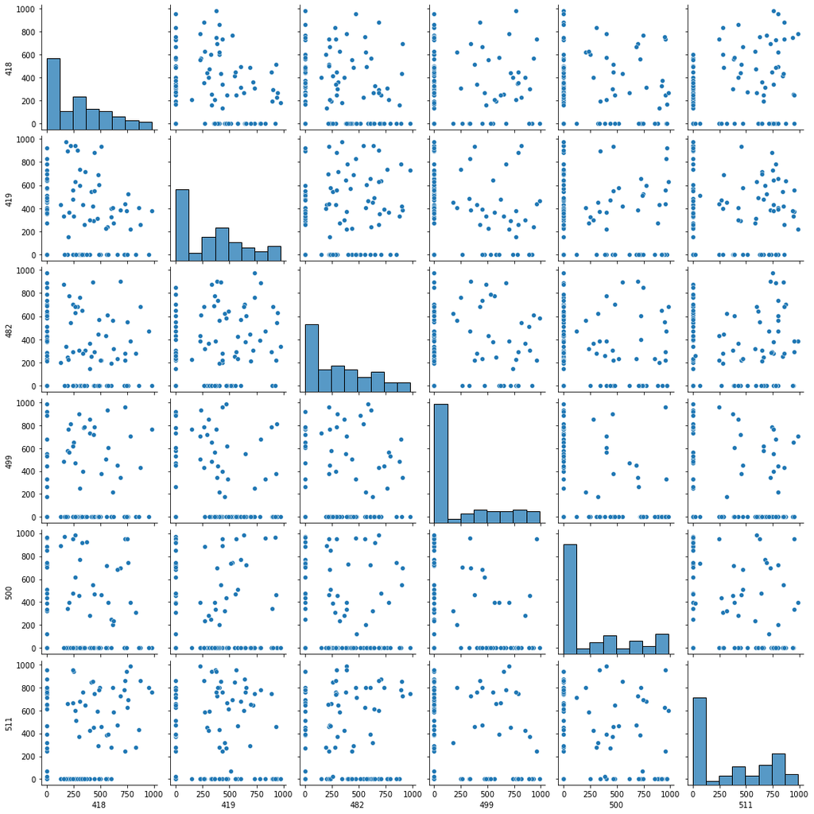

```python
sns.pairplot(x.value) #Observe the diagonal columns here for distributions
```

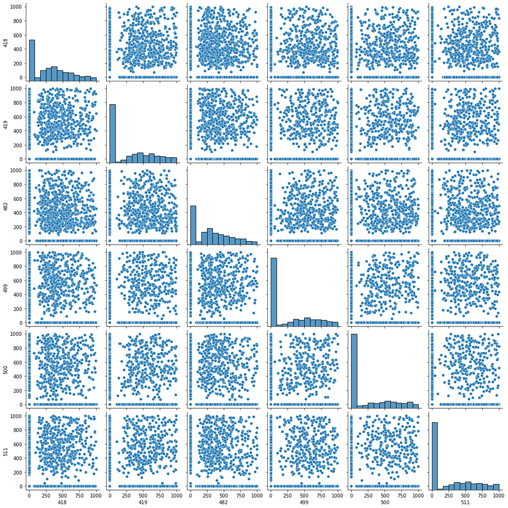

```python
sns.pairplot(y.value) # this is the pass case Scenario
```

There is something extremely wrong with these sensors. They show unusual distributions in both Pass case and fail case Scenario. That means they are also irelevant in their outcome. But, also they note a large amount of distribution having variation but those variations doesn't seem to be accountable to either Pass case or Fail case.

There might be some kind of counter balancing i.e. negative proportion and a cycle happening in the control systems with Root locus feedback loop responding to those non-zero values and might be correcting the manufacturing. If that is the assumption, then we can conclude two things 1. Those control systems were successful a lot of the times thereby making some potential Fail case into a Pass case 2. Those control systems terribly failed in some cases of these, which might have resulted in the fail case.

Also note that these sensors, themselves don't show any kind of clustering or relationship. It is perplexing. If those Sensors were really responding to or noting anamolies, that would mean that a bunch of sensors following it might also be seeing some kind of relationship or variance with these sensors. It should be difference for various scenarios. But, it is not so, hence the assumption is weak and unverifiable at this point.

It would be extremely important to study these sensors. But for the sake of Normalization, taking that the above assumption is out of my side to challenge or verify, I would simply assume these sensor values as anamolies and will add to the list of useless sensors.

```python
Note_taking_list.append(["Drop the columns",sensor_of_interest,"All the dataframes"])
```

```python
###########################################################
x.clear()
y.clear()
z.clear() # clearing variables for next use.
###########################################################
a=variable()
b=variable() # Initializing some variables for use.
#############################################################
```

```python
###########################################
x.value=data1_target_wo_main
y.value=data1_notarget_wo_main
########################################
a.value=data1_target_wo_main.describe()
b.value=data1_notarget_wo_main.describe()
###########################################
###########################################
p=variable()
f=variable()
###########################################
p.value=outliers_list_pass_case_df #temporary assignment for working case.
f.value=outliers_list_fail_case_df
###########################################
```

```python
#a.value
```

```python
#x.value
```

```python
#p.value
```

```python
std_deviation_level=3
############################################################################
#You can carefully craft this as acceptable standard deviation level and find out appropriately. I have no idea
#what is the right level. I hope it is 3.
# This is also later referred to as a Threshold value.
#
##########################################################################
##########################################################################
def check_for_outliers_bool(dataframe):
    df=dataframe.describe()
    sensor_log=[]
    #print(df)
    for col in dataframe.columns:
        ky1=False
        ky2=False
        if df[col].loc["min"]<std_deviation_level*df[col].loc["min"]:
            ky1=True
        elif df[col].loc["max"]>std_deviation_level*df[col].loc["max"]:
            ky2=True
        else:
            pass
        if ky1 & ky2:
            sensor_log.append([col,1,1])
        elif (ky1) & (not(ky2)):
            sensor_log.append([col,1,-1])
        elif (not(ky1)) & (ky2):
            sensor_log.append([col,-1,1])
        elif (not(ky1)) & (not(ky2)):
            sensor_log.append([col,-1,-1])
    return sensor_log
##########################################################################
##########################################################################
sensor_log_pass=check_for_outliers_bool(y.value) #Outliers for each sensor and what type of outliers are those
sensor_log_fail=check_for_outliers_bool(x.value) #Outliers for each sensor and what type of outliers are those.
```

```python
#sensor_log_pass # Uncomment this to actually view those sensors and what kind of outliers are there in those sensors.
```

1. When sensors are over driven in Pass case ocassionally but are strictly within the limits in Fail case (these are mysterious sensors or just regular sensors reporting false values due to some reason)
2. When sensors are over driven in Fail case ocassionally but are strictly within the limits in Pass case. This indicates that those sensors might be key indicators on the idea that sensors are driven into overdrive forecasting some kind of manufacturing defect.

The combinations are as below : case 1. (1,1) = Has both Quartile1 and Quartile3 outliers beyond the given range in that column case 2. (1,-1) = Has only Quartile 1 Outliers beyond the given range in that column case 3. (-1,1) = Has only Quartile 3 Outliers beyond the given range in that column case 4. (-1,-1) = Has no Quartile 1 or Quartile 3 Outliers beyond the given range in that column.

**Notes and Implications** :

Each of these might be considered case by case basis for more deeper analysis. We might consider creating a dataframe or table such that these scenarios are checked out appropriately and conclusions can be drawn. case 1. This if compared against both scenarios yeilds the same kind of result for same kind of sensors, it means that those sensors are properly working and that is their normal way of working. (Probable inspection and recalibration suggested ?) case 2 & 3. If case 2 in Fail case scenario intersection with case1 in Pass case scenario or vice-versa that means some sensors have flipped their information or have been driven insane. So, if we create a table kind of view and check these cases for each scenario, we might get different conclusions on it. case 4. This in either case true in one scenario but not in other scenario means that sensors are being driven at extremum points are brought into control by Pass case, or being driven in range but is being pushed out of range (in either direction) by the faulty manufacturing

**Beware** : Beware that sensors might be interconnected, and that these sensors might have direct connection with sensors are vice-versa in the production outputs.

We might have to write a new function to actually find out those outlier values and also the datapoints within each of these scenarios to find out exactly what datapoints are those and, within those limits, if there is any correspondence/relationship to the prediction/Scenario guesstimation.

```python
z=variable()
z.value=[] # This will hold outliers that are inside the Fail case but are not in the pass case.
q=variable()
q.value=[] # This will hold outliers that are inside Pass case but not in fail case
#This captures what type of threshold is crossed in pass case or fail case
##########################################################
for index in range(len(sensor_log_pass)):
    k=difference_in_list(sensor_log_fail[index],sensor_log_pass[index])
    r=difference_in_list(sensor_log_pass[index],sensor_log_fail[index])
    if len(k):
        z.value.append((index,k))
    if len(r):
        q.value.append((index,r))
##########################################################
print(z.value)
print("\n")
print(q.value)
# Please note that
print(len(z.value))
print(len(q.value))
```

```
[(3, [1]), (6, [1]), (19, [1]), (20, [1]), (23, [1]), (24, [1]), (25, [1]), (39, [1]), (66, [1]), (104, [1]), (120, [1]), (131, [1]), (134, [1]), (149, [1]), (150, [1]), (151, [1]), (152, [1]), (153, [1]), (154, [1]), (155, [1]), (182, [1]), (183, [1]), (212, [1]), (228, [1]), (231, [1]), (246, [1])…


[]
48
0
```

We possibly hit the jackpot here. We have identified 48 unique sensors that have flipped in Fail case scenario (gone low) but have stayed still in pass scenario.

**Observations and Statements** :

1. These are the sensors which have been recorded as a pass value or outlier in the Fail case scenario but have no outliers in the Pass case scenario. The number 1 indicates what type of outlier it is (in here they indicate outlier for minimum) Quartile1 outlier. So, since it is a Quartile1 outlier, that means those particular sensors indicate presence of minimum values lesser than expected for a normal distribution.
2. Those sensors didn't have similar type of outlier in the Pass case but have the kind (sensors going lower than minimum threshold) of outlier in the Fail case Scenario. Indicating that those particular sensors were sensing output lesser than usual, but were not sensing same kind of less output in case of Pass case Scenario.
3. The sensors that have shown extreme values in Pass case but haven't shown such in Fail case is zero. Means the rest of the sensors, that do have some kind of extreme values, are most likely (highly doubtful) be due to sensor anamolies.

**Please Note** : I am not writing a generalized function here to extract these sensors and check their statistics. I am just writing a general loops. Hence, it is neglected on what type of outlier lies, since it is taken that the observer has already seen the cell above and has noted down the observations and statements mentioned. Hence, they are not being addressed in a more general sense.

```python
interesting_sensor_collection=[] #Storing value from the temporary variable into more permanent ones.
########################################################
for each in z.value:
    interesting_sensor_collection.append(str(each[0]))
#########################################################
z.clear()
q.clear()
#interesting_sensor_collection #Uncomment this to see what those interesting columns are
```

**Some Propositions and Notes**: Since our threshold setting and identifying the patterns and sensors is over, we can go to the next step of outlier treatment. It will be as follows :

We will take sensors in the latest expedition, make them a list and keep them aside. Then check the whole list of the outliers for a particular column. If the outliers count is crossing a certain number/certain proportion, that means the data for that particular sensor is not peaked at a particular point (we will deal with one example first).

That means, those sensors are not centrally peaked and normally distributed. Under such condition, need to first check for the same in both Pass case and Fail case scenarios.

Furthering our assertions, it usually means three things :

1. Either those are once again useless sensors and can be added to useless sensors list, if they exhibit same behaviour in both scenarios,
2. Or that if they do differ with cases, that means there are different ranges/peaks for different scenarios, indicating a very strong correlation between Pass/Fail output,
3. Or that they have a. No defined precision value for the sensor for ideal output (negating our assumptions) or b. They are calibrated to be freely allowed to roam in that particular range (highly unlikely for precision process like semiconductor manufacturing where cutting edge technology is used and precision is the key). It all depends on histplot that we are going to witness of them.

We will decide what the threshold outlier count will be.

```python
print(b.value[interesting_sensor_collection[3]]) #Description for that particular sensor in Pass case
print(a.value[interesting_sensor_collection[3]]) #Description for that particular sensor in Fail case
```

```
count    1463.000000
mean        1.404951
std         0.016878
min         1.179700
25%         1.396500
50%         1.405900
75%         1.414750
max         1.453400
Name: 20, dtype: float64
count    104.000000
mean       1.406513
std        0.014603
min        1.364300
25%        1.397125
50%        1.406850
75%        1.417100
max        1.437200
Name: 20, dtype: float64
```

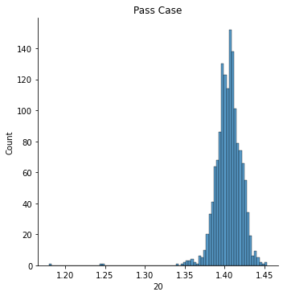

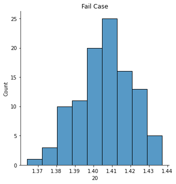

```python
#plt.figure()
#plt.subplot(1,2,1)
sns.displot(x=y.value[interesting_sensor_collection[3]])
plt.title("Pass Case")
#plt.subplot(1,2,2)
sns.displot(x=x.value[interesting_sensor_collection[3]])
plt.title("Fail Case")
plt.show()
```

We will look at another of those interesting sensors.

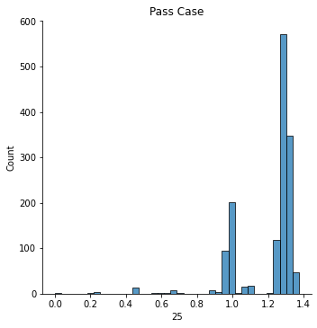

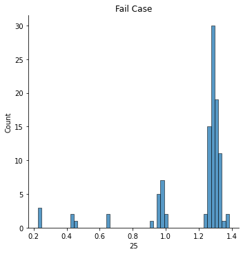

```python
#plt.figure()
#plt.subplot(1,2,1)
sns.displot(x=y.value[interesting_sensor_collection[6]])
plt.title("Pass Case")
#plt.subplot(1,2,2)
sns.displot(x=x.value[interesting_sensor_collection[6]])
plt.title("Fail Case")
plt.show()
```

```python
#interesting_sensor_collection
o=variable() # Initializing another variable
####################################################################
z.value=data1_wo[interesting_sensor_collection+["Pass/Fail"]]
####################################################################
z.value.corr()
```

|  | 3 | 6 | 19 | 20 | 23 | 24 | 25 | 39 | 66 | 104 | ... | 349 | 350 | 351 | 353 | 378 | 379 | 381 | 403 | 408 | Pass/Fail |
| --- | --- | --- | --- | --- | --- | --- | --- | --- | --- | --- | --- | --- | --- | --- | --- | --- | --- | --- | --- | --- | --- |
| 3 | 1.000000 | -0.685835 | 0.040405 | 0.038042 | -0.008007 | -0.049772 | 0.079853 | 0.021367 | -0.027368 | -0.014026 | ... | 0.033162 | -0.023170 | -0.050813 | -0.099006 | NaN | NaN | NaN | NaN | 0.053637 | -0.024631 |
| 6 | -0.685835 | 1.000000 | -0.006166 | -0.035269 | 0.013088 | 0.057657 | -0.098358 | 0.006108 | 0.038078 | -0.000922 | ... | -0.006172 | 0.020570 | 0.061153 | 0.023377 | NaN | NaN | NaN | NaN | -0.037160 | 0.016244 |
| 19 | 0.040405 | -0.006166 | 1.000000 | 0.031181 | -0.003859 | 0.037956 | -0.018209 | -0.029181 | 0.007203 | 0.061083 | ... | 0.021276 | 0.012102 | 0.006770 | -0.049925 | NaN | NaN | NaN | NaN | 0.004478 | 0.030657 |
| 20 | 0.038042 | -0.035269 | 0.031181 | 1.000000 | -0.017899 | -0.025729 | 0.052258 | -0.008249 | -0.048068 | -0.025686 | ... | 0.002604 | 0.032970 | -0.006800 | -0.030789 | NaN | NaN | NaN | NaN | 0.001845 | 0.023253 |
| 23 | -0.008007 | 0.013088 | -0.003859 | -0.017899 | 1.000000 | 0.030027 | -0.123955 | 0.011147 | 0.007575 | 0.016459 | ... | -0.017879 | 0.066850 | 0.037609 | -0.011997 | NaN | NaN | NaN | NaN | 0.003256 | 0.012932 |
| 24 | -0.049772 | 0.057657 | 0.037956 | -0.025729 | 0.030027 | 1.000000 | -0.241482 | -0.030372 | 0.005208 | 0.019287 | ... | 0.013257 | 0.015051 | 0.054511 | 0.022971 | NaN | NaN | NaN | NaN | 0.037352 | -0.018380 |
| 25 | 0.079853 | -0.098358 | -0.018209 | 0.052258 | -0.123955 | -0.241482 | 1.000000 | 0.042931 | 0.067015 | -0.003304 | ... | -0.028484 | -0.065156 | -0.142883 | 0.016071 | NaN | NaN | NaN | NaN | -0.008409 | -0.036545 |
| 39 | 0.021367 | 0.006108 | -0.029181 | -0.008249 | 0.011147 | -0.030372 | 0.042931 | 1.000000 | 0.009184 | -0.016988 | ... | 0.021907 | -0.042353 | 0.004104 | 0.016334 | NaN | NaN | NaN | NaN | 0.017586 | -0.002127 |
| 66 | -0.027368 | 0.038078 | 0.007203 | -0.048068 | 0.007575 | 0.005208 | 0.067015 | 0.009184 | 1.000000 | -0.040300 | ... | -0.011868 | -0.017119 | 0.011051 | 0.051807 | NaN | NaN | NaN | NaN | 0.008622 | -0.039032 |
| 104 | -0.014026 | -0.000922 | 0.061083 | -0.025686 | 0.016459 | 0.019287 | -0.003304 | -0.016988 | -0.040300 | 1.000000 | ... | -0.023994 | 0.008716 | 0.007041 | -0.018423 | NaN | NaN | NaN | NaN | -0.037184 | -0.038848 |
| 120 | -0.011802 | 0.027625 | -0.018552 | -0.025870 | -0.033879 | 0.011331 | -0.002361 | 0.030355 | 0.018268 | -0.013186 | ... | 0.032711 | 0.011297 | -0.004783 | -0.027763 | NaN | NaN | NaN | NaN | 0.041647 | -0.020277 |
| 131 | 0.006882 | 0.033823 | 0.018809 | 0.019431 | 0.036877 | 0.039800 | -0.009010 | -0.039663 | 0.006114 | -0.012004 | ... | -0.021168 | 0.041508 | 0.032901 | -0.021246 | NaN | NaN | NaN | NaN | -0.030989 | 0.017982 |
| 134 | 0.042901 | -0.021290 | 0.043278 | 0.010411 | 0.007505 | -0.043894 | 0.011179 | 0.050970 | 0.028279 | -0.026749 | ... | 0.085230 | 0.030701 | -0.006588 | -0.003687 | NaN | NaN | NaN | NaN | -0.025244 | -0.030558 |
| 149 | NaN | NaN | NaN | NaN | NaN | NaN | NaN | NaN | NaN | NaN | ... | NaN | NaN | NaN | NaN | NaN | NaN | NaN | NaN | NaN | NaN |
| 150 | -0.046359 | 0.080224 | 0.012829 | 0.017752 | 0.012298 | 0.019077 | -0.031532 | 0.002274 | -0.029569 | -0.030369 | ... | 0.004547 | -0.002674 | 0.031990 | -0.017642 | NaN | NaN | NaN | NaN | -0.014879 | -0.012131 |
| 151 | -0.005753 | -0.011374 | 0.013141 | -0.018342 | -0.035155 | 0.015928 | 0.013831 | -0.031891 | -0.066758 | 0.027699 | ... | -0.010750 | -0.013547 | 0.018580 | -0.009901 | NaN | NaN | NaN | NaN | -0.008031 | -0.022416 |
| 152 | 0.007971 | 0.027884 | 0.007582 | 0.019630 | -0.007956 | 0.016055 | -0.035796 | -0.003697 | 0.017437 | -0.011457 | ... | -0.003241 | 0.031425 | 0.004062 | -0.015342 | NaN | NaN | NaN | NaN | 0.033087 | -0.004610 |
| 153 | -0.049002 | 0.019861 | -0.037325 | -0.037951 | -0.007317 | 0.029187 | -0.103739 | 0.000375 | -0.004043 | -0.000482 | ... | 0.064941 | 0.017440 | 0.088880 | -0.001425 | NaN | NaN | NaN | NaN | -0.066276 | 0.021713 |
| 154 | 0.013506 | -0.003375 | 0.003155 | 0.016887 | -0.004024 | 0.003014 | -0.036377 | -0.004112 | 0.021230 | -0.014840 | ... | -0.003784 | 0.033862 | -0.002476 | -0.000098 | NaN | NaN | NaN | NaN | 0.039736 | 0.001565 |
| 155 | -0.035666 | 0.011154 | -0.805518 | -0.025564 | 0.008371 | -0.026696 | 0.010207 | 0.002137 | -0.010558 | -0.117670 | ... | -0.010219 | -0.005171 | -0.001364 | 0.027800 | NaN | NaN | NaN | NaN | -0.019044 | -0.026458 |
| 182 | 0.022853 | 0.028525 | 0.028217 | -0.037658 | -0.010611 | -0.004083 | 0.042199 | -0.024012 | 0.255233 | 0.005795 | ... | -0.006994 | -0.022871 | -0.028846 | 0.015669 | NaN | NaN | NaN | NaN | -0.000181 | -0.031270 |
| 183 | -0.021078 | 0.026617 | 0.008204 | 0.011887 | -0.003535 | 0.046929 | -0.033302 | 0.003269 | -0.083312 | -0.029667 | ... | 0.011068 | 0.016577 | 0.014897 | -0.029849 | NaN | NaN | NaN | NaN | 0.005712 | 0.055603 |
| 212 | -0.026986 | 0.019412 | 0.013148 | 0.033137 | 0.066117 | 0.016051 | -0.064765 | -0.041917 | -0.026571 | 0.005235 | ... | 0.022676 | 0.993534 | 0.022122 | 0.022152 | NaN | NaN | NaN | NaN | -0.008320 | 0.002495 |
| 228 | -0.027332 | 0.018466 | -0.002360 | -0.023596 | -0.041637 | 0.030564 | -0.069075 | -0.001252 | 0.009815 | -0.044579 | ... | 0.032032 | 0.036823 | 0.044882 | -0.002517 | NaN | NaN | NaN | NaN | 0.000349 | 0.011054 |
| 231 | NaN | NaN | NaN | NaN | NaN | NaN | NaN | NaN | NaN | NaN | ... | NaN | NaN | NaN | NaN | NaN | NaN | NaN | NaN | NaN | NaN |
| 246 | 0.014908 | -0.053536 | 0.011965 | 0.010665 | -0.009119 | 0.008221 | -0.026547 | 0.016530 | -0.030321 | 0.016761 | ... | 0.000970 | -0.045042 | 0.012018 | 0.045406 | NaN | NaN | NaN | NaN | -0.004196 | -0.008177 |
| 247 | -0.006137 | 0.014918 | -0.070600 | -0.016977 | -0.010601 | -0.063797 | -0.074691 | 0.135869 | -0.107325 | -0.052060 | ... | 0.005295 | 0.061938 | 0.086123 | 0.004957 | NaN | NaN | NaN | NaN | -0.001094 | 0.080991 |
| 248 | -0.033133 | 0.014853 | 0.008592 | -0.028265 | -0.017045 | -0.007893 | -0.057087 | -0.009066 | -0.033492 | 0.008428 | ... | -0.036334 | -0.002472 | 0.027309 | -0.014485 | NaN | NaN | NaN | NaN | -0.028358 | 0.008912 |
| 249 | -0.028192 | -0.000124 | -0.000663 | -0.033351 | 0.013338 | 0.025125 | -0.065182 | -0.002852 | -0.054014 | 0.004061 | ... | -0.061218 | -0.020095 | 0.016740 | -0.018288 | NaN | NaN | NaN | NaN | 0.011277 | 0.066478 |
| 250 | -0.040085 | 0.023839 | -0.026765 | -0.001040 | -0.039558 | -0.037868 | 0.015684 | 0.008924 | 0.027880 | 0.000052 | ... | -0.032693 | 0.031899 | -0.001539 | 0.003386 | NaN | NaN | NaN | NaN | -0.024449 | 0.006964 |
| 251 | 0.032365 | -0.013646 | 0.001297 | -0.008267 | -0.020072 | 0.000124 | -0.004865 | 0.005728 | 0.075706 | 0.006648 | ... | 0.001737 | -0.017354 | -0.004732 | -0.038429 | NaN | NaN | NaN | NaN | -0.008373 | -0.010315 |
| 252 | 0.039671 | -0.041630 | 0.010718 | 0.020560 | 0.001351 | 0.004202 | 0.014379 | 0.002038 | -0.023527 | -0.007900 | ... | 0.034754 | -0.022652 | 0.017487 | -0.045242 | NaN | NaN | NaN | NaN | 0.003862 | -0.006634 |
| 279 | 0.009566 | -0.029972 | 0.027463 | -0.017043 | -0.000499 | -0.033550 | 0.037531 | -0.000497 | 0.082417 | -0.027655 | ... | -0.060542 | -0.046322 | -0.028034 | 0.089120 | NaN | NaN | NaN | NaN | 0.033915 | -0.038352 |
| 280 | -0.067915 | 0.075644 | 0.010362 | -0.013790 | 0.007299 | 0.005998 | 0.025094 | -0.048849 | 0.005719 | 0.025122 | ... | 0.110492 | -0.044989 | -0.035368 | -0.020142 | NaN | NaN | NaN | NaN | 0.003814 | -0.050465 |
| 313 | NaN | NaN | NaN | NaN | NaN | NaN | NaN | NaN | NaN | NaN | ... | NaN | NaN | NaN | NaN | NaN | NaN | NaN | NaN | NaN | NaN |
| 329 | NaN | NaN | NaN | NaN | NaN | NaN | NaN | NaN | NaN | NaN | ... | NaN | NaN | NaN | NaN | NaN | NaN | NaN | NaN | NaN | NaN |
| 332 | 0.006251 | 0.013962 | 0.011615 | 0.003600 | -0.018914 | 0.000304 | 0.024797 | 0.015750 | 0.080691 | 0.024693 | ... | -0.011602 | -0.025755 | -0.010544 | 0.004874 | NaN | NaN | NaN | NaN | 0.000510 | 0.034726 |
| 345 | 0.025884 | -0.003022 | 0.020226 | 0.007279 | -0.002559 | -0.009312 | 0.000410 | -0.005152 | 0.079968 | -0.008626 | ... | -0.010077 | -0.028966 | 0.063546 | -0.014282 | NaN | NaN | NaN | NaN | 0.044955 | -0.003116 |
| 346 | 0.015942 | -0.005462 | 0.023972 | 0.011563 | -0.009128 | -0.007262 | -0.012594 | -0.007483 | 0.033898 | -0.008471 | ... | -0.003833 | -0.025848 | 0.078719 | -0.012988 | NaN | NaN | NaN | NaN | 0.042924 | -0.003084 |
| 349 | 0.033162 | -0.006172 | 0.021276 | 0.002604 | -0.017879 | 0.013257 | -0.028484 | 0.021907 | -0.011868 | -0.023994 | ... | 1.000000 | 0.023435 | 0.040984 | -0.042076 | NaN | NaN | NaN | NaN | -0.012226 | 0.045108 |
| 350 | -0.023170 | 0.020570 | 0.012102 | 0.032970 | 0.066850 | 0.015051 | -0.065156 | -0.042353 | -0.017119 | 0.008716 | ... | 0.023435 | 1.000000 | 0.023819 | 0.024587 | NaN | NaN | NaN | NaN | -0.009092 | 0.003138 |
| 351 | -0.050813 | 0.061153 | 0.006770 | -0.006800 | 0.037609 | 0.054511 | -0.142883 | 0.004104 | 0.011051 | 0.007041 | ... | 0.040984 | 0.023819 | 1.000000 | -0.044232 | NaN | NaN | NaN | NaN | -0.023148 | 0.043081 |
| 353 | -0.099006 | 0.023377 | -0.049925 | -0.030789 | -0.011997 | 0.022971 | 0.016071 | 0.016334 | 0.051807 | -0.018423 | ... | -0.042076 | 0.024587 | -0.044232 | 1.000000 | NaN | NaN | NaN | NaN | 0.018399 | -0.019015 |
| 378 | NaN | NaN | NaN | NaN | NaN | NaN | NaN | NaN | NaN | NaN | ... | NaN | NaN | NaN | NaN | NaN | NaN | NaN | NaN | NaN | NaN |
| 379 | NaN | NaN | NaN | NaN | NaN | NaN | NaN | NaN | NaN | NaN | ... | NaN | NaN | NaN | NaN | NaN | NaN | NaN | NaN | NaN | NaN |
| 381 | NaN | NaN | NaN | NaN | NaN | NaN | NaN | NaN | NaN | NaN | ... | NaN | NaN | NaN | NaN | NaN | NaN | NaN | NaN | NaN | NaN |
| 403 | NaN | NaN | NaN | NaN | NaN | NaN | NaN | NaN | NaN | NaN | ... | NaN | NaN | NaN | NaN | NaN | NaN | NaN | NaN | NaN | NaN |
| 408 | 0.053637 | -0.037160 | 0.004478 | 0.001845 | 0.003256 | 0.037352 | -0.008409 | 0.017586 | 0.008622 | -0.037184 | ... | -0.012226 | -0.009092 | -0.023148 | 0.018399 | NaN | NaN | NaN | NaN | 1.000000 | -0.027316 |
| Pass/Fail | -0.024631 | 0.016244 | 0.030657 | 0.023253 | 0.012932 | -0.018380 | -0.036545 | -0.002127 | -0.039032 | -0.038848 | ... | 0.045108 | 0.003138 | 0.043081 | -0.019015 | NaN | NaN | NaN | NaN | -0.027316 | 1.000000 |

49 rows × 49 columns

From these noting these special sensors that show correlation what so ever from this very list and saving them temporarily.

```python
o.value=["403","381","379","378","313","329","231","149"]
#saving these sensors for analysis

o.value
```

```
['403', '381', '379', '378', '313', '329', '231', '149']
```

```python
data1_wo[o.value].describe()
```

|  | 403 | 381 | 379 | 378 | 313 | 329 | 231 | 149 |
| --- | --- | --- | --- | --- | --- | --- | --- | --- |
| count | 1558.0 | 1561.0 | 1561.0 | 1561.0 | 1543.0 | 1563.0 | 1561.0 | 1564.0 |
| mean | 0.0 | 0.0 | 0.0 | 0.0 | 0.0 | 0.0 | 0.0 | 0.0 |
| std | 0.0 | 0.0 | 0.0 | 0.0 | 0.0 | 0.0 | 0.0 | 0.0 |
| min | 0.0 | 0.0 | 0.0 | 0.0 | 0.0 | 0.0 | 0.0 | 0.0 |
| 25% | 0.0 | 0.0 | 0.0 | 0.0 | 0.0 | 0.0 | 0.0 | 0.0 |
| 50% | 0.0 | 0.0 | 0.0 | 0.0 | 0.0 | 0.0 | 0.0 | 0.0 |
| 75% | 0.0 | 0.0 | 0.0 | 0.0 | 0.0 | 0.0 | 0.0 | 0.0 |
| max | 0.0 | 0.0 | 0.0 | 0.0 | 0.0 | 0.0 | 0.0 | 0.0 |

```python
#checking to see if these particular columns are present in the modified main dataframes that we have created. Looks like they aren't.
print(any(item in x.value.columns for item in o.value))
print(any(item in y.value.columns for item in o.value))
print(any(item in x.value.columns for item in o.value)) #If they are in pass case scenario or fail case scenario.
#remember that if we drop columns we have to drop them in both or else we have treat them in both.
```

```
False
False
False
```

Seems like these are interesecting cases and have already been taken care of in the previous stage of dropping some useless column.

All we can do now, is check for more interesting patterns within the interesting_sensor_collection after dropping these useless columns after some note taking.

```python
Note_taking_list.append(["Delete columns",o.value,"From total dataframe"])
```

```python
#plt.figure(figsize=(20,12))
#mf(sns.heatmap(z.value.corr(),annot=True)) #checking in the original dataframe for any of the correlations
#plt.show()
```

```python
#z.value.corr() #Uncomment this to view the interesting data
```

```python
#plt.figure(figsize=(20,12))
#mf(sns.heatmap(z.value.cov(),annot=True)) #checking in the original dataframe for any of the covariances
#plt.show()
```

```python
# A small checking of if any of the sensors mentioned here are also the ones in those useless list of sensors.
print(difference_in_list(sensor_of_interest,interesting_sensor_collection)) # This crux of sensors are of no value.
print(difference_in_list(interesting_sensor_collection,sensor_of_interest)) #This crux of sensors to be retained
print(difference_in_list(useless_sensors_list_fail,sensor_of_interest)) #Coincidence of useless sensors vs useless sensors. Interesting.
print(set(interesting_sensor_collection).intersection(set(sensor_of_interest))) #Temporarily storing these sensor values
q.clear()
z.clear() # Clearing the now useless variables
q.value=set(interesting_sensor_collection).intersection(set(useless_sensors_list_fail)) #These are another set of sensors.
```

```
['418', '419', '482', '499', '500', '511']
['3', '6', '19', '20', '23', '24', '25', '39', '66', '104', '120', '131', '134', '149', '150', '151', '152', '153', '154', '155', '182', '183', '212', '228', '231', '246', '247', '248', '249', '250', '251', '252', '279', '280', '313', '329', '332', '345', '346', '349', '350', '351', '353', '378', '3…
['5', '13', '42', '49', '52', '69', '97', '141', '149', '178', '179', '186', '189', '190', '191', '192', '193', '194', '226', '229', '230', '231', '232', '233', '234', '235', '236', '237', '240', '241', '242', '243', '256', '257', '258', '259', '260', '261', '262', '263', '264', '265', '266', '276',…
set()
```

Seems like there are some sensors that are in sensor_of_interest, that are not in interesting_sensor_collection. As we have already decided that those sensors that are not worth keeping, it is interesting to see if they have something in common here for the sensors that are found out as useless here.

Interesting to see what patterns follow from these two sets of sensors i.e. q.value and the leftover sensors after dropping o.value from them.

```python
print(any(value in sensor_of_interest for value in o.value))
if any(value in useless_sensors_list_fail for value in o.value) :
    print(difference_in_list(useless_sensors_list_fail,interesting_sensor_collection))
if any(value in useless_sensors_list_fail for value in o.value) :
    print(difference_in_list(interesting_sensor_collection,useless_sensors_list_fail))
```

```
False
['5', '13', '42', '49', '52', '69', '97', '141', '178', '179', '186', '189', '190', '191', '192', '193', '194', '226', '229', '230', '232', '233', '234', '235', '236', '237', '240', '241', '242', '243', '256', '257', '258', '259', '260', '261', '262', '263', '264', '265', '266', '276', '284', '314',…
['3', '6', '19', '20', '23', '24', '25', '39', '66', '104', '120', '131', '134', '150', '151', '152', '153', '154', '155', '182', '183', '212', '228', '246', '247', '248', '249', '250', '251', '252', '279', '280', '332', '345', '346', '349', '350', '351', '353', '408']
```

We now see that some sensors listed here are also listed in those set of useless sensors too. So, so far we have three lists of sensors 1.Useless_sensors_fail_na 2.sensor_of_interest (ironically is also completely useless)

1. interesting_sensor_collection - which requires removal of useless sensors from it. But as the calculation here indicates that there is common elements between both of them.

```python
for each in o.value:
    interesting_sensor_collection.remove(each) # Removing those useless sensors from these and sending for further analysis.
```

```python
any(value in interesting_sensor_collection for value in o.value) #Making sure that it is cleaned indeed.
```

```
False
```

```python
o.clear() # Clear and reinitialize for further analysis.
o.value=interesting_sensor_collection
```

```python
print(len(q.value))
print(len(o.value))
```

```
8
40
```

```python
print(any(value in x.value.columns for value in o.value))
```

```
True
```

```python
print(any(value in useless_sensors_list_fail for value in q.value)) # Check if these sensors are already involved in the deleted versions.
print(all(value in useless_sensors_list_fail for value in q.value))
```

```
True
True
```

```
Time taken = 5.3647801876068115 seconds
```

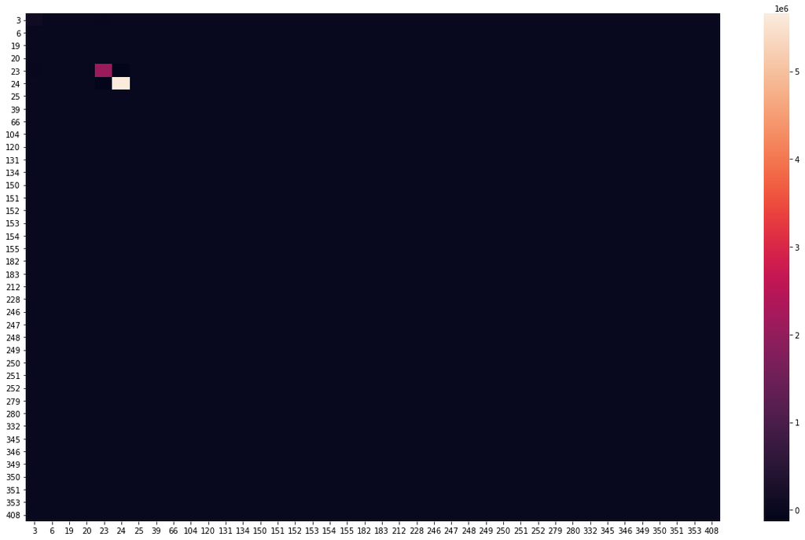

```python
plt.figure(figsize=(20,12))
mf(sns.heatmap(data=data1_target_wo[o.value].cov()))
plt.show()
```

So, these sensors have no special case, they are like any other sensors.

Now that we have dealt with all possible pattern recognitions and explorations with the data, we have a strategy to follow so that we have data ready.

**Conclusions and Further Steps in Analysis**

**Strategy** :

1. Eliminate irrelevant sensors from the both Pass case and fail case scenarios.
2. Find out the outliers and NaN values (we have already done this)
3. Define an integer threshold parameter for considering how distribution is to be dealt with as Normal distribution and what not. We will assign this as a special parameter, or data entry point, or a separate dataframe, depending upon the size of the data.
4. We define another parameter called proportion parameters (which can perhaps be tuned depending upon how many sensors and how significant each are taking the list of values of significance (scale) given for each sensor). We will give equal proportion for all sensors, but it can always be adjusted. (It can be modified such that we have "0" as a value for irrelevant sensors indicating that they are completely dropped. We don't have deeplearning mechanism to self set these values or tweak them and learn). Depending upon those proportion threshold, if the outlier proportion lie beyond that threshold for that particular sensor, we will deal with the two conditions case by case basis.

**case 1**. Outliers are not within the threshold proportion : In this case we check if the particular sensor is normally distributed. If it is, we replace the outlier with the Mean value. If it is not normally distributed, we will check the modal value for that particular sensor. If the highest value mode exceeds a certain proportion (to be decided based on the importance of the sensor given by the user in the previously discussed proportion parameters, but we will fix it as a parameter based on the importance of the sensor based on the previous scale). Usually if we want more precision in our manufacturing, we should have very little variations and highest modal value. In pass case scenario we will replace those values with median and in fail case scenario we will replace them with mode value.